# Framed Listening: NLP Model Comparison — Top & Bottom Semantic Similarity Pairs

Author

Hazel A. van der Walle (PhD student, Music, Durham University)

Published

April 23, 2026

All datasets generated and used for this study are openly available on GitHub: https://github.com/HazelvdW/context-framed-listening.

**Why both levels for all models?**

Running every model on both levels reveals two things that a partial comparison cannot: (1) whether a model’s behaviour changes substantially with input length and aggregation, and (2) whether the performance advantages of sentence-embedding models over TF-IDF/Word2Vec are consistent across scales. TF-IDF and Word2Vec are expected to perform poorly at the individual level due to sparse lexical overlap. Seeing that failure empirically, alongside the scores each model assigns to the same conceptually similar pairs, is the evidence needed to justify model choices.

> **Cross-level similarity scores are not directly comparable** — the units differ (64 documents vs many individual responses). Cross-model comparisons are run within each group separately. The distributions section gives the best high-level view of how each model behaves across both levels.

**All models × both levels:**

|  | TF-IDF | W2V `lvl2a` | W2V `lvl1a` | BERT | BERTweet | para-MiniLM | MiniLM | mpnet | para-mpnet |
| --- | --- | --- | --- | --- | --- | --- | --- | --- | --- |
| **A — combMIMC** | A1 | A2 | A3 | A4 | A5 | A6 | A7 | A8 | A9 |
| **B — individual** | B1 | B2 | B3 | B4 | B5 | B6 | B7 | B8 | B9 |

## Setup

```
Using virtual environment '/Users/hazelaileenvanderwalle/.virtualenvs/r-reticulate' ...
```

```
+ /Users/hazelaileenvanderwalle/.virtualenvs/r-reticulate/bin/python -m pip install --upgrade --no-user pandas numpy scikit-learn scipy matplotlib seaborn sentence-transformers torch gensim
```

```
Output directory: /Users/hazelaileenvanderwalle/Library/CloudStorage/OneDrive-Personal/work/study/PhD/_PROJECT/_framedListening_NLP/context-framed-listening/NLP_outputs/model_comparison
```

```
Showing top/bottom 10 pairs per model
```

```
Python 3.9.6 (default, Jan  9 2026, 11:03:41)
[Clang 17.0.0 (clang-1700.6.4.2)]
```

```
  numpy                      2.0.2        OK
  pandas                     2.3.3        OK
  scipy                      1.13.1       OK
  sklearn                    1.6.1        OK
  matplotlib                 3.9.4        OK
  seaborn                    0.13.2       OK
  sentence_transformers      5.1.2        OK
  torch                      2.8.0        OK
  gensim                     4.4.0        OK
```

```
All package versions OK.
```

## Load Data

```
combMIMC_lvl2a: 64 documents | columns: ['context_word', 'genre_code', 'clip_name', 'ClipContext_pair', 'GenreContext_pair', 'textMIMC_lvl2a', 'text_original']
```

```
combMIMC_lvl1a: 64 documents | columns: ['context_word', 'genre_code', 'clip_name', 'ClipContext_pair', 'GenreContext_pair', 'textMIMC_lvl1a', 'text_original']
```

```
dataMIMC_preprocessed: 1946 individual responses
```

```
   Original text column: 'descr_THOUGHT.text_spellchecked'
```

## Helper Functions

```
Helper functions defined.
```

# Group A — Aggregated combMIMC (N = 64)

## A1 — TF-IDF

**Data**: `combMIMC_lvl2a.csv` | **Preprocessing**: `lvl2a` (aggressive)

Bag-of-words similarity: texts are similar only if they share rare words. No understanding of meaning — “furious” and “angry” score zero similarity. Expected to be most meaningful at the aggregated level where documents are long enough for word overlap to be informative.

```
A1 — TF-IDF  (combMIMC_lvl2a)
```

```
  Pairs: 2,016  |  skipped — identical: 0  |  short (<5 words): 0  |  same person/cell: 0
```

```
TOP 10:

  [1]  Sim=0.3213  |  ✓ same clip  ✗ diff context
       Jaz_MED_07 / bar  vs  Jaz_MED_07 / movie
  ── Original A: i thought about a mystery or crime film i thought about a black and white film where the main character is a detective from the 50s and the woman playing the piano is in a red dress at a bar it seemed very old school to me | a movie character sitting in a bar drinking all alone afte…
  ── Original B: sounds cosy | in my bedroom studying for an important exam with various books open while i read | it was the music youd expect to hear as the hero entered a villains bar or lounge in a noir movie | a movie scene in a speakeasy black and white or the brown filter whose name i cannot …
     Model A:    mystery crime black white main character detective woman red dress seem old school endofinput character sit drink alone bad news receive endofinput lowkey speakeasy popular place quiet one hidden gem place antique furniture low light endofinput nothing specific come late night old c…
     Model B:    cosy endofinput bedroom study important exam various book open read endofinput youd expect hear hero enter villain lounge noir endofinput speakeasy black white brown filter whose name maybe detective drinking hard day endofinput character cafe dim warm yellowish lighting endofinput …

  [2]  Sim=0.3080  |  ✓ same clip  ✗ diff context
       Ele_LOW_14 / bar  vs  Ele_LOW_14 / concert
  ── Original A: feels very busy like i am driving around doing something important something is happening going on or i have a task i need to do urgently | makes me think of those gaming bars where you drink and they have old games consoles like pac man etc or in a 70s 80s 90s themed bar | i imagin…
  ── Original B: i thought about an old sonic game i thought about the original sonic map and sonic running around i thought about the jumping noise that he makes | myself playing contra its a video game in my bedroom sitting on the floor with my back against my bed | a rave lots of strobe lighting …
     Model A:    feel busy drive around something important something happen go task need urgently endofinput drink old console pac man etc theme endofinput rave several lead strobe light everyones fun dance around partner endofinput feel rip straight level shovel knight dunno though never beat they…
     Model B:    old sonic original sonic map sonic run around jumping noise endofinput contra bedroom sit floor back bed endofinput rave lot strobe lighting people jump huge room full people light strobe flashing light endofinput start start blade couple second switch classic grow family gamers bos…

  [3]  Sim=0.2920  |  ✓ same clip  ✗ diff context
       Jaz_MED_07 / bar  vs  Jaz_MED_07 / concert
  ── Original A: i thought about a mystery or crime film i thought about a black and white film where the main character is a detective from the 50s and the woman playing the piano is in a red dress at a bar it seemed very old school to me | a movie character sitting in a bar drinking all alone afte…
  ── Original B: i imagined myself in a restaurant maybe in the usa rather than the uk a calm evening meal probably at somewhere quite posh | in my mind i could see a jazz bar similar to one you might see in the 1920s there is a couple dancing nearby there is colored woman on stage taking a break fr…
     Model A:    mystery crime black white main character detective woman red dress seem old school endofinput character sit drink alone bad news receive endofinput lowkey speakeasy popular place quiet one hidden gem place antique furniture low light endofinput nothing specific come late night old c…
     Model B:    restaurant maybe usa rather uk calm evening meal probably somewhere quite posh endofinput mind see similar one might see couple dancing nearby color woman stage take break air fill smell cigarette smoke body odour endofinput feel nice cozy nook endofinput give dim lit nightclub perf…

  [4]  Sim=0.2891  |  ✓ same clip  ✗ diff context
       Jaz_MED_07 / concert  vs  Jaz_MED_07 / movie
  ── Original A: i imagined myself in a restaurant maybe in the usa rather than the uk a calm evening meal probably at somewhere quite posh | in my mind i could see a jazz bar similar to one you might see in the 1920s there is a couple dancing nearby there is colored woman on stage taking a break fr…
```

[output cut: 45 more lines]

```
BOTTOM 10:

  [1]  Sim=0.0501  |  ✗ diff clip  ✗ diff context
       Met_LOW_09 / concert  vs  Ele_MED_20 / videogame
  ── Original A: very heavy rock not for me somewhere that i do not belong did not enjoy | middle aged men who ride motorbikes with long grey beards mosh pits dark night time concert loud headbanging | i imagined my self watching a bunch of heavy metal songs with my favorite headset on | it felt lik…
  ── Original B: i could see a loading screen for a video game an anime girl sitting on a seat in the window knees to her chest its cozy but also futuristic outside the window it seems to be raining above a cityscape we seem to be very high above the ground the clouds are blocking the view downwards…
     Model A:    heavy somewhere belong enjoy endofinput middle age men ride motorbike long grey beard mosh pit dark night time loud headbanging endofinput self watch bunch heavy favorite headset endofinput felt melodic death endofinput sort different kind expect bit shout hint endofinput cacophony …
     Model B:    see loading screen anime girl sit seat window knee chest cozy also futuristic outside window seem rain cityscape seem high ground cloud block view downwards endofinput felt spacey chill vibe endofinput give nostalgic feel cousin afternoon summer endofinput weird alien vibe kind surf…

  [2]  Sim=0.0507  |  ✗ diff clip  ✗ diff context
       Jaz_MED_07 / concert  vs  Met_MED_20 / videogame
  ── Original A: i imagined myself in a restaurant maybe in the usa rather than the uk a calm evening meal probably at somewhere quite posh | in my mind i could see a jazz bar similar to one you might see in the 1920s there is a couple dancing nearby there is colored woman on stage taking a break fr…
  ── Original B: very charged maybe you have won something or won a battle hyped up possibly ending credits meant to be good | not sure where this would fit cannot especially imagine it working very well | sort of reminds me of a few racing mobile games i used to play on my first real smartphone ver…
     Model A:    restaurant maybe usa rather uk calm evening meal probably somewhere quite posh endofinput mind see similar one might see couple dancing nearby color woman stage take break air fill smell cigarette smoke body odour endofinput feel nice cozy nook endofinput give dim lit nightclub perf…
     Model B:    charge maybe something battle hype possibly end credit mean good endofinput sure fit especially work well endofinput sort racing mobile use first real smartphone nostalgic endofinput avenged sevenfold endofinput hero endofinput usually beginning adventure subway surf sport car racin…

  [3]  Sim=0.0543  |  ✗ diff clip  ✗ diff context
       Jaz_MED_02 / concert  vs  Met_MED_20 / videogame
  ── Original A: when i was a kid spending an afternoon with my grandma doing jigsaw puzzles | first thought was the greatest video game of all time la noir its straight out of a 40s jazz club or a prohibition era speakeasy | at first i could imagine a browser window with a cafe ambient video playin…
  ── Original B: very charged maybe you have won something or won a battle hyped up possibly ending credits meant to be good | not sure where this would fit cannot especially imagine it working very well | sort of reminds me of a few racing mobile games i used to play on my first real smartphone ver…
     Model A:    kid spend afternoon grandma jigsaw puzzle endofinput first great time la noir straight club prohibition era speakeasy endofinput first browser window cafe ambient see universtys starbucks full view saw inside though id step inside watch student sip coffee tap away laptop endofinput …
     Model B:    charge maybe something battle hype possibly end credit mean good endofinput sure fit especially work well endofinput sort racing mobile use first real smartphone nostalgic endofinput avenged sevenfold endofinput hero endofinput usually beginning adventure subway surf sport car racin…

  [4]  Sim=0.0545  |  ✗ diff clip  ✓ same context
       Jaz_LOW_21 / movie  vs  Met_LOW_09 / movie
  ── Original A: very peppy like lift music again feels busy like you need to do something maybe walking through a shopping center listening to this in the background | fun supermarket shopping scene in a coming of age movie | reminds me of a tom jerry show i used to watch the sound track playing in…
```

[output cut: 45 more lines]

```
Saved: /Users/hazelaileenvanderwalle/Library/CloudStorage/OneDrive-Personal/work/study/PhD/_PROJECT/_framedListening_NLP/context-framed-listening/NLP_outputs/model_comparison/pairs_A1_tfidf.png
```

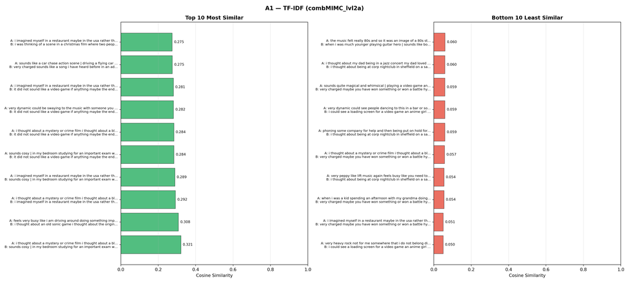

## A2 — Word2Vec (`lvl2a`)

**Data**: `combMIMC_lvl2a.csv` | **Preprocessing**: `lvl2a` (aggressive)

Static word embeddings averaged per document. Captures semantic relatedness (“furious” ≈ “angry”) unlike TF-IDF, but loses word order and sentence structure.

> Pre-trained `word2vec-google-news-300` vectors (~1.6 GB). Downloads once and caches.

```
A2 — Word2Vec lvl2a  (combMIMC_lvl2a)
```

```
Loaded Word2Vec from cache.
```

```
  Pairs: 2,016  |  skipped — identical: 0  |  short (<5 words): 0  |  same person/cell: 0
```

```
TOP 10:

  [1]  Sim=0.9782  |  ✗ diff clip  ✗ diff context
       Jaz_MED_02 / bar  vs  Jaz_MED_07 / videogame
  ── Original A: very dynamic could be swaying to the music with someone you care about could be sat with a drink alone thinking about your life something important | again jazz bar in new york city cocktails flowing older clientele everyone nicely dressed atmospheric lighting | i imagined my self w…
  ── Original B: it did not sound like a video game if anything maybe the end credits or something again sounded like something sad or emotional youd hear being played in a bar makes you reflect on your life while having a drink alone | does not fit with what i would imagine for a video game but doe…
     Model A:    dynamic sway someone care sit drink alone life something important endofinput new york city cocktail flow old clientele everyone nicely dress atmospheric lighting endofinput self watch live feel nostalgic nod head rhythm endofinput felt old tv show someone sit alone wait someone nev…
     Model B:    anything maybe end credit something something sad emotional youd hear reflect life drink alone endofinput fit character walk high end club specifically new york city fit slow move endofinput self old school slow dance friend sip glass wine endofinput classic lounge prohibition era s…

  [2]  Sim=0.9749  |  ✗ diff clip  ✗ diff context
       Jaz_MED_02 / bar  vs  Jaz_MED_07 / concert
  ── Original A: very dynamic could be swaying to the music with someone you care about could be sat with a drink alone thinking about your life something important | again jazz bar in new york city cocktails flowing older clientele everyone nicely dressed atmospheric lighting | i imagined my self w…
  ── Original B: i imagined myself in a restaurant maybe in the usa rather than the uk a calm evening meal probably at somewhere quite posh | in my mind i could see a jazz bar similar to one you might see in the 1920s there is a couple dancing nearby there is colored woman on stage taking a break fr…
     Model A:    dynamic sway someone care sit drink alone life something important endofinput new york city cocktail flow old clientele everyone nicely dress atmospheric lighting endofinput self watch live feel nostalgic nod head rhythm endofinput felt old tv show someone sit alone wait someone nev…
     Model B:    restaurant maybe usa rather uk calm evening meal probably somewhere quite posh endofinput mind see similar one might see couple dancing nearby color woman stage take break air fill smell cigarette smoke body odour endofinput feel nice cozy nook endofinput give dim lit nightclub perf…

  [3]  Sim=0.9738  |  ✓ same clip  ✗ diff context
       Jaz_MED_07 / concert  vs  Jaz_MED_07 / videogame
  ── Original A: i imagined myself in a restaurant maybe in the usa rather than the uk a calm evening meal probably at somewhere quite posh | in my mind i could see a jazz bar similar to one you might see in the 1920s there is a couple dancing nearby there is colored woman on stage taking a break fr…
  ── Original B: it did not sound like a video game if anything maybe the end credits or something again sounded like something sad or emotional youd hear being played in a bar makes you reflect on your life while having a drink alone | does not fit with what i would imagine for a video game but doe…
     Model A:    restaurant maybe usa rather uk calm evening meal probably somewhere quite posh endofinput mind see similar one might see couple dancing nearby color woman stage take break air fill smell cigarette smoke body odour endofinput feel nice cozy nook endofinput give dim lit nightclub perf…
     Model B:    anything maybe end credit something something sad emotional youd hear reflect life drink alone endofinput fit character walk high end club specifically new york city fit slow move endofinput self old school slow dance friend sip glass wine endofinput classic lounge prohibition era s…

  [4]  Sim=0.9732  |  ✗ diff clip  ✓ same context
       Jaz_MED_02 / bar  vs  Jaz_MED_07 / bar
  ── Original A: very dynamic could be swaying to the music with someone you care about could be sat with a drink alone thinking about your life something important | again jazz bar in new york city cocktails flowing older clientele everyone nicely dressed atmospheric lighting | i imagined my self w…
```

[output cut: 45 more lines]

```
BOTTOM 10:

  [1]  Sim=0.8114  |  ✗ diff clip  ✓ same context
       Jaz_MED_07 / movie  vs  Met_LOW_14 / movie
  ── Original A: sounds cosy | in my bedroom studying for an important exam with various books open while i read | it was the music youd expect to hear as the hero entered a villains bar or lounge in a noir movie | a movie scene in a speakeasy black and white or the brown filter whose name i cannot …
  ── Original B: a mix of things that should not be together does not sound right or meshed well to me too much going on not sure what part of a movie it would fit sounded confusing | the clip reminds me of a popular jason statham action movie i watched a few years ago the main actor being chased by…
     Model A:    cosy endofinput bedroom study important exam various book open read endofinput youd expect hear hero enter villain lounge noir endofinput speakeasy black white brown filter whose name maybe detective drinking hard day endofinput character cafe dim warm yellowish lighting endofinput …
     Model B:    mix thing together right mesh well much go sure part fit confuse endofinput popular jason statham action watch year ago main actor chase bad guy cop endofinput someone put backing modern take mega man big fight modernize rom hack endofinput felt envision suspenseful bos fight endofi…

  [2]  Sim=0.8165  |  ✗ diff clip  ✗ diff context
       80s_LOW_06 / bar  vs  Met_LOW_14 / movie
  ── Original A: the music felt really 80s and so it was an image of a 80s style hawaiian bar with hula style decor | the music evokes the feeling of wanting to dance with friends | it made me think about my husband and i miss him wanted to dance and laugh with him just listening to this music sound…
  ── Original B: a mix of things that should not be together does not sound right or meshed well to me too much going on not sure what part of a movie it would fit sounded confusing | the clip reminds me of a popular jason statham action movie i watched a few years ago the main actor being chased by…
     Model A:    felt really style hawaiian hula style decor endofinput evoke feeling want dance friend endofinput husband miss want dance laugh listen endofinput friend celebratory mood saxophonist give u special solo help u enjoy already happy night endofinput course somebody drink go severally gr…
     Model B:    mix thing together right mesh well much go sure part fit confuse endofinput popular jason statham action watch year ago main actor chase bad guy cop endofinput someone put backing modern take mega man big fight modernize rom hack endofinput felt envision suspenseful bos fight endofi…

  [3]  Sim=0.8183  |  ✗ diff clip  ✗ diff context
       80s_LOW_06 / bar  vs  Met_LOW_14 / videogame
  ── Original A: the music felt really 80s and so it was an image of a 80s style hawaiian bar with hula style decor | the music evokes the feeling of wanting to dance with friends | it made me think about my husband and i miss him wanted to dance and laugh with him just listening to this music sound…
  ── Original B: i was thinking of a scene from pokemon maybe in a battle maybe from an episode i wouldve watched 15 to 20 years ago | i can see a big futuristic boss with a well armed character who is flitting around dodging slamming sword attacks whilst managing to get in a few attacks themselves …
     Model A:    felt really style hawaiian hula style decor endofinput evoke feeling want dance friend endofinput husband miss want dance laugh listen endofinput friend celebratory mood saxophonist give u special solo help u enjoy already happy night endofinput course somebody drink go severally gr…
     Model B:    pokemon maybe battle maybe episode wouldve watch year ago endofinput see big futuristic bos well arm character flit around dodge slam sword attack whilst manage get attack bos slam sword character run along take bos endofinput enjoy seem mashup genre endofinput immediately scenario …

  [4]  Sim=0.8189  |  ✗ diff clip  ✗ diff context
       Jaz_MED_07 / movie  vs  Met_LOW_14 / videogame
  ── Original A: sounds cosy | in my bedroom studying for an important exam with various books open while i read | it was the music youd expect to hear as the hero entered a villains bar or lounge in a noir movie | a movie scene in a speakeasy black and white or the brown filter whose name i cannot …
```

[output cut: 45 more lines]

```
Saved: /Users/hazelaileenvanderwalle/Library/CloudStorage/OneDrive-Personal/work/study/PhD/_PROJECT/_framedListening_NLP/context-framed-listening/NLP_outputs/model_comparison/pairs_A2_w2v_lvl2a.png
```

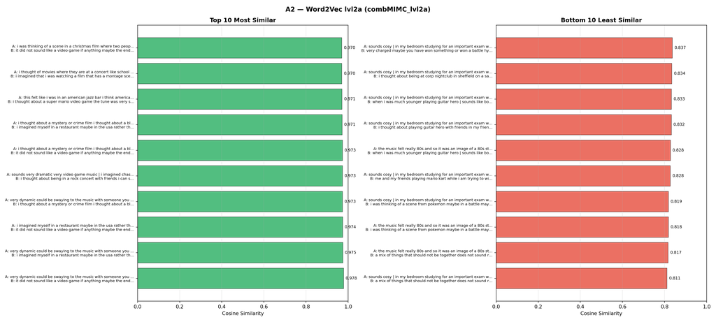

## A3 — Word2Vec (`lvl1a`)

**Data**: `combMIMC_lvl1a.csv` | **Preprocessing**: `lvl1a` (light)

Same model as A2 on lighter-preprocessed text. Comparing A2 vs A3 isolates the preprocessing effect on Word2Vec. Comparing A3 vs A4 (BERT) isolates contextualisation, since both receive identical `lvl1a` input.

```
A3 — Word2Vec lvl1a  (combMIMC_lvl1a)
```

```
  Pairs: 2,016  |  skipped — identical: 0  |  short (<5 words): 0  |  same person/cell: 0
```

```
TOP 10:

  [1]  Sim=0.9882  |  ✗ diff clip  ✗ diff context
       Met_MED_20 / bar  vs  Met_MED_19 / concert
  ── Original A: i thought of movies where they are at a concert like school of rock or something similar and they are in a mosh pit | i can see myself at the computer desk as a kid opening up spotify to see what avenged sevenfold song was playing whilst doing homework on the computer and talking to…
  ── Original B: i imagined that i was watching a film that has a montage scene like an action comedy one i could not actively imagine being at a concert like this | a heavy metal gig or festival | when i hear this i think of my sister and i as kids listening to music like this banging our heads pre…
     Model A:    i of where they are at a school of or something similar and they are in a mosh pit endofinput i can see myself at the computer desk as a kid opening up spotify to see what avenged sevenfold was whilst doing homework on the computer and talking to some friends on facebook at the time…
     Model B:    i that i was watching a that has a montage an action comedy one i not actively being at a this endofinput a heavy gig or festival endofinput when i hear this i of my sister and i as kids listening to this banging our heads pretending to air our hair get all crazy but it was always s…

  [2]  Sim=0.9881  |  ✗ diff clip  ✓ same context
       Met_MED_19 / concert  vs  Met_MED_20 / concert
  ── Original A: i imagined that i was watching a film that has a montage scene like an action comedy one i could not actively imagine being at a concert like this | a heavy metal gig or festival | when i hear this i think of my sister and i as kids listening to music like this banging our heads pre…
  ── Original B: i thought about being in a rock concert with friends i can see myself looking to my right and left and being in the middle of a huge body of people i can see me and my friends jumping up and down and enjoying the guitar solo | one of those white people music concerts where the artis…
     Model A:    i that i was watching a that has a montage an action comedy one i not actively being at a this endofinput a heavy gig or festival endofinput when i hear this i of my sister and i as kids listening to this banging our heads pretending to air our hair get all crazy but it was always s…
     Model B:    i about being in a with friends i can see myself looking to my right and left and being in the middle of a huge body of people i can see me and my friends jumping up and down and enjoying the solo endofinput one of those white people where the artist a and they go wild but its a nic…

  [3]  Sim=0.9873  |  ✗ diff clip  ✓ same context
       Met_MED_19 / movie  vs  Met_MED_20 / movie
  ── Original A: this scene reminded me of one of my favorite wrestlers his theme music during his entrance is extremely similar to this song i thought about watching him wrestling live with friends and having a great time | a music concert with drummers getting lit | i thought of a chase scene the …
  ── Original B: driving my car really fast and recklessly while just about keeping it on the road | it sounded like anime credits or opening title sequence music | not a movie no idea what weird movie would have that music but a concert sounded like avenge sevenfold the sort of music video i used t…
     Model A:    this reminded me of one of my favorite wrestlers his theme during his entrance is extremely similar to this i about watching him wrestling live with friends and having a great time endofinput a with drummers getting lit endofinput i of a chase the protagonist is running through a ci…
     Model B:    driving my car really fast and recklessly while just about keeping it on the road endofinput it anime credits or opening title sequence endofinput not a no idea what weird have that but a avenge sevenfold the sort of i used to see on kerrang endofinput the resonates my one lost in t…

  [4]  Sim=0.9871  |  ✓ same clip  ✗ diff context
       Jaz_MED_07 / bar  vs  Jaz_MED_07 / concert
  ── Original A: i thought about a mystery or crime film i thought about a black and white film where the main character is a detective from the 50s and the woman playing the piano is in a red dress at a bar it seemed very old school to me | a movie character sitting in a bar drinking all alone afte…
```

[output cut: 45 more lines]

```
BOTTOM 10:

  [1]  Sim=0.9117  |  ✗ diff clip  ✗ diff context
       80s_LOW_06 / bar  vs  Met_LOW_14 / movie
  ── Original A: the music felt really 80s and so it was an image of a 80s style hawaiian bar with hula style decor | the music evokes the feeling of wanting to dance with friends | it made me think about my husband and i miss him wanted to dance and laugh with him just listening to this music sound…
  ── Original B: a mix of things that should not be together does not sound right or meshed well to me too much going on not sure what part of a movie it would fit sounded confusing | the clip reminds me of a popular jason statham action movie i watched a few years ago the main actor being chased by…
     Model A:    the felt really 80s and so it was an of a 80s style hawaiian with hula style decor endofinput the evokes the feeling of wanting to dance with friends endofinput it me about my husband and i miss him wanted to dance and laugh with him just listening to this endofinput i myself and a …
     Model B:    a mix of things that should not be together does not right or meshed well to me too much going on not sure what part of a it fit confusing endofinput the me of a popular jason statham action i watched a few years ago the main actor being chased by the bad guys or the cops endofinput…

  [2]  Sim=0.9141  |  ✗ diff clip  ✓ same context
       Jaz_MED_07 / movie  vs  Met_LOW_14 / movie
  ── Original A: sounds cosy | in my bedroom studying for an important exam with various books open while i read | it was the music youd expect to hear as the hero entered a villains bar or lounge in a noir movie | a movie scene in a speakeasy black and white or the brown filter whose name i cannot …
  ── Original B: a mix of things that should not be together does not sound right or meshed well to me too much going on not sure what part of a movie it would fit sounded confusing | the clip reminds me of a popular jason statham action movie i watched a few years ago the main actor being chased by…
     Model A:    cosy endofinput in my bedroom studying for an important exam with various books open while i read endofinput it was the youd expect to hear as the hero entered a villains or lounge in a noir endofinput a in a speakeasy black and white or the brown filter whose name i can not maybe a…
     Model B:    a mix of things that should not be together does not right or meshed well to me too much going on not sure what part of a it fit confusing endofinput the me of a popular jason statham action i watched a few years ago the main actor being chased by the bad guys or the cops endofinput…

  [3]  Sim=0.9163  |  ✗ diff clip  ✗ diff context
       Jaz_MED_07 / movie  vs  Ele_LOW_14 / videogame
  ── Original A: sounds cosy | in my bedroom studying for an important exam with various books open while i read | it was the music youd expect to hear as the hero entered a villains bar or lounge in a noir movie | a movie scene in a speakeasy black and white or the brown filter whose name i cannot …
  ── Original B: me and my friends playing mario kart while i am trying to win | it sounds like music from a 90s video game or an arcade machine | pac man some annoying game from the 80s very irritating music a sort of pixelated game | i imagined a pixelated combination scroller moving from left to …
     Model A:    cosy endofinput in my bedroom studying for an important exam with various books open while i read endofinput it was the youd expect to hear as the hero entered a villains or lounge in a noir endofinput a in a speakeasy black and white or the brown filter whose name i can not maybe a…
     Model B:    me and my friends mario kart while i am trying to win endofinput it from a 90s or an arcade machine endofinput pac man some annoying from the 80s very irritating a sort of pixelated endofinput i a pixelated combination scroller moving from left to right paper mario and fighting mort…

  [4]  Sim=0.9185  |  ✗ diff clip  ✗ diff context
       80s_LOW_06 / bar  vs  Met_LOW_14 / videogame
  ── Original A: the music felt really 80s and so it was an image of a 80s style hawaiian bar with hula style decor | the music evokes the feeling of wanting to dance with friends | it made me think about my husband and i miss him wanted to dance and laugh with him just listening to this music sound…
```

[output cut: 45 more lines]

```
Saved: /Users/hazelaileenvanderwalle/Library/CloudStorage/OneDrive-Personal/work/study/PhD/_PROJECT/_framedListening_NLP/context-framed-listening/NLP_outputs/model_comparison/pairs_A3_w2v_lvl1a.png
```

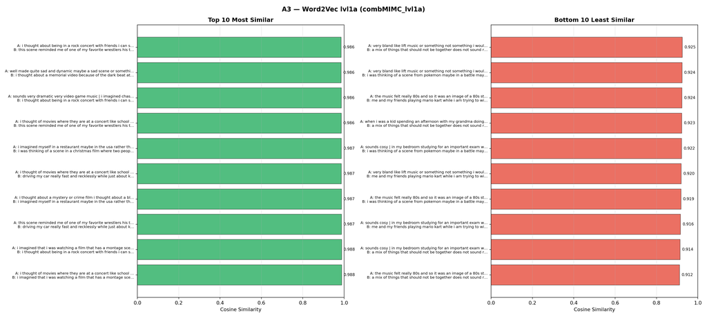

## A4 — BERT

**Data**: `combMIMC_lvl1a.csv` | **Preprocessing**: `lvl1a` (light)

Contextualised embeddings with mean-pooling. Not fine-tuned for similarity, so the embedding space may not be optimally structured for cosine comparison — but it captures word meaning in context, unlike A3 (Word2Vec).

```
A4 — BERT  (combMIMC_lvl1a)
```

```
Loaded from cache: (64, 768)
```

```
  Pairs: 2,016  |  skipped — identical: 0  |  short (<5 words): 0  |  same person/cell: 0
```

```
TOP 10:

  [1]  Sim=0.9834  |  ✓ same clip  ✗ diff context
       Ele_MED_19 / bar  vs  Ele_MED_19 / movie
  ── Original A: this felt like i was listening to a lofi beats spotify playlist its quite relaxing | a rainy day and a forest | i can see myself in a car as a passenger rain rolling down the windows as we drive on the interstate just outside of boston the sky is gloomy and there is so much fog in t…
  ── Original B: well made quite sad and dynamic maybe a sad scene or something is being revealed doing something important maybe walking in the rain or going to do something you should not be | initially imagined it to be a piece playing over a sad moment of the movie however as the beat was added …
     Model A:    this felt i was listening to a lofi beats spotify playlist its quite relaxing endofinput a rainy day and a forest endofinput i can see myself in a car as a passenger rain rolling down the windows as we drive on the interstate just outside of boston the sky is gloomy and there is so …
     Model B:    well quite sad and dynamic maybe a sad or something is being revealed doing something important maybe walking in the rain or going to do something you should not be endofinput initially it to be a over a sad moment of the however as the beat was added it fit more with a coming of ag…

  [2]  Sim=0.9815  |  ✗ diff clip  ✓ same context
       80s_LOW_02 / bar  vs  Jaz_MED_02 / bar
  ── Original A: kind of sad melancholy not happy or upbeat emotionally charged | made me imagine a high end bar with atmospheric lighting with candles or small lamps on tables cocktails old fashioned etc young bar staff dressed in black and white | reminds me of back in the days my dad used to cons…
  ── Original B: very dynamic could be swaying to the music with someone you care about could be sat with a drink alone thinking about your life something important | again jazz bar in new york city cocktails flowing older clientele everyone nicely dressed atmospheric lighting | i imagined my self w…
     Model A:    kind of sad melancholy not happy or upbeat emotionally charged endofinput me a high end with atmospheric lighting with candles or small lamps on tables cocktails old fashioned etc young staff dressed in black and white endofinput me of back in the days my dad used to constantly kenn…
     Model B:    very dynamic be swaying to the with someone you care about be sat with a drink alone about your life something important endofinput again in new york city cocktails flowing older clientele everyone nicely dressed atmospheric lighting endofinput i my self watching a live and feeling …

  [3]  Sim=0.9814  |  ✗ diff clip  ✗ diff context
       Ele_MED_19 / bar  vs  80s_MED_13 / movie
  ── Original A: this felt like i was listening to a lofi beats spotify playlist its quite relaxing | a rainy day and a forest | i can see myself in a car as a passenger rain rolling down the windows as we drive on the interstate just outside of boston the sky is gloomy and there is so much fog in t…
  ── Original B: imagine it in a science fiction movie | i imagined the korean movies i used to binge watch when i was around the age of 14 to 16 i had just gotten back from school and after getting my assignments sorted out my favorite korean show was next in line | it sounded like it could be an i…
     Model A:    this felt i was listening to a lofi beats spotify playlist its quite relaxing endofinput a rainy day and a forest endofinput i can see myself in a car as a passenger rain rolling down the windows as we drive on the interstate just outside of boston the sky is gloomy and there is so …
     Model B:    it in a science fiction endofinput i the korean i used to binge watch when i was around the age of 14 to 16 i had just gotten back from school and after getting my assignments sorted out my favorite korean show was next in line endofinput it it be an introduction to some romantic tv…

  [4]  Sim=0.9813  |  ✓ same clip  ✗ diff context
       Jaz_LOW_21 / bar  vs  Jaz_LOW_21 / concert
  ── Original A: phoning some company for help and then being put on hold for a long time while this music plays | it sounds like elevator music or the music you get on a call when you are put on hold would also fit a generic supermarket in a movie | music in some sort of speakeasy if you have ever …
```

[output cut: 45 more lines]

```
BOTTOM 10:

  [1]  Sim=0.9095  |  ✗ diff clip  ✗ diff context
       Jaz_MED_07 / concert  vs  Ele_LOW_14 / videogame
  ── Original A: i imagined myself in a restaurant maybe in the usa rather than the uk a calm evening meal probably at somewhere quite posh | in my mind i could see a jazz bar similar to one you might see in the 1920s there is a couple dancing nearby there is colored woman on stage taking a break fr…
  ── Original B: me and my friends playing mario kart while i am trying to win | it sounds like music from a 90s video game or an arcade machine | pac man some annoying game from the 80s very irritating music a sort of pixelated game | i imagined a pixelated combination scroller moving from left to …
     Model A:    i myself in a restaurant maybe in the usa rather than the uk a calm evening meal probably at somewhere quite posh endofinput in my mind i see a similar to one you might see in the 1920s there is a couple dancing nearby there is colored woman on stage taking a break from singing the …
     Model B:    me and my friends mario kart while i am trying to win endofinput it from a 90s or an arcade machine endofinput pac man some annoying from the 80s very irritating a sort of pixelated endofinput i a pixelated combination scroller moving from left to right paper mario and fighting mort…

  [2]  Sim=0.9114  |  ✗ diff clip  ✗ diff context
       Ele_MED_20 / bar  vs  Ele_LOW_14 / videogame
  ── Original A: sounds futuristic ambient | the music relates to moments where one is traveling solo to explore new things | serenepeacefulthoughtful and peaceful | i felt at peace while listening to this it made me calm and feel present in the moment | this one reminds me of a nigerian movie i wat…
  ── Original B: me and my friends playing mario kart while i am trying to win | it sounds like music from a 90s video game or an arcade machine | pac man some annoying game from the 80s very irritating music a sort of pixelated game | i imagined a pixelated combination scroller moving from left to …
     Model A:    futuristic ambient endofinput the relates to moments where one is traveling solo to explore new things endofinput serenepeacefulthoughtful and peaceful endofinput i felt at peace while listening to this it me calm and feel present in the moment endofinput this one me of a nigerian i…
     Model B:    me and my friends mario kart while i am trying to win endofinput it from a 90s or an arcade machine endofinput pac man some annoying from the 80s very irritating a sort of pixelated endofinput i a pixelated combination scroller moving from left to right paper mario and fighting mort…

  [3]  Sim=0.9135  |  ✗ diff clip  ✗ diff context
       Jaz_MED_07 / movie  vs  Ele_LOW_14 / videogame
  ── Original A: sounds cosy | in my bedroom studying for an important exam with various books open while i read | it was the music youd expect to hear as the hero entered a villains bar or lounge in a noir movie | a movie scene in a speakeasy black and white or the brown filter whose name i cannot …
  ── Original B: me and my friends playing mario kart while i am trying to win | it sounds like music from a 90s video game or an arcade machine | pac man some annoying game from the 80s very irritating music a sort of pixelated game | i imagined a pixelated combination scroller moving from left to …
     Model A:    cosy endofinput in my bedroom studying for an important exam with various books open while i read endofinput it was the youd expect to hear as the hero entered a villains or lounge in a noir endofinput a in a speakeasy black and white or the brown filter whose name i can not maybe a…
     Model B:    me and my friends mario kart while i am trying to win endofinput it from a 90s or an arcade machine endofinput pac man some annoying from the 80s very irritating a sort of pixelated endofinput i a pixelated combination scroller moving from left to right paper mario and fighting mort…

  [4]  Sim=0.9136  |  ✗ diff clip  ✗ diff context
       Jaz_MED_02 / movie  vs  Ele_LOW_14 / videogame
  ── Original A: i was thinking of a scene in a christmas film where two people are in a posh restaurant | a jazz bar or slow dance in a movie scene | i can see a jazz stage the instruments on the side a curtain slowing raising show a beautifully dressed woman who is about to sing | i could imagine …
```

[output cut: 45 more lines]

```
Saved: /Users/hazelaileenvanderwalle/Library/CloudStorage/OneDrive-Personal/work/study/PhD/_PROJECT/_framedListening_NLP/context-framed-listening/NLP_outputs/model_comparison/pairs_A4_bert.png
```

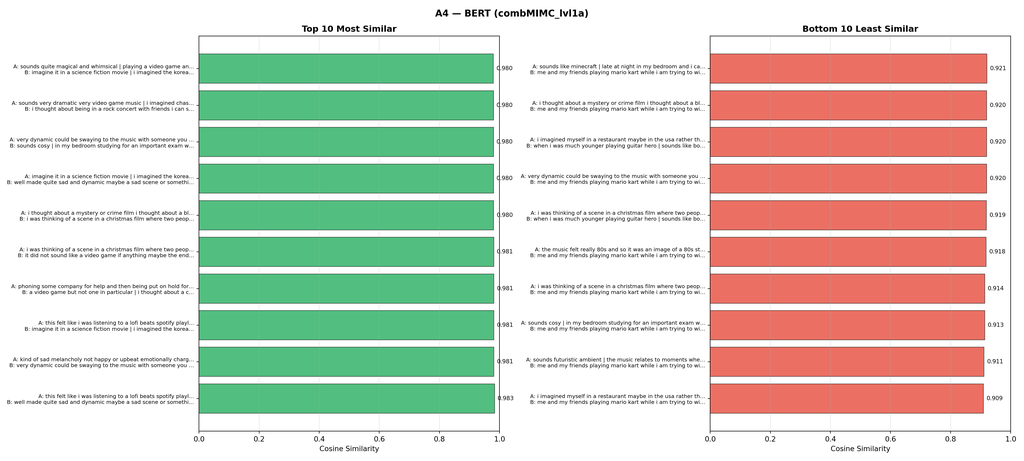

## A5 — BERTweet

**Data**: `combMIMC_lvl1a.csv` | **Preprocessing**: `lvl1a` (light)

BERTweet (`vinai/bertweet-base`) is a RoBERTa-based model pretrained on 850M English tweets. Its vocabulary and pretraining domain are oriented toward short, informal text — making it a meaningful contrast to `bert-base-uncased` (pretrained on books and Wikipedia) when applied to short individual MIMC descriptions. Max sequence length is 128 tokens. Like BERT, it is not fine-tuned for similarity, so embeddings are mean-pooled and compared via cosine similarity. Comparing A4 vs A5 isolates pretraining domain (formal vs informal text) while keeping architecture and similarity method constant.

```
A5 — BERTweet  (combMIMC_lvl1a)
```

```
Loaded from cache: (64, 768)
```

```
  Pairs: 2,016  |  skipped — identical: 0  |  short (<5 words): 0  |  same person/cell: 0
```

```
TOP 10:

  [1]  Sim=0.9725  |  ✗ diff clip  ✗ diff context
       Jaz_MED_07 / bar  vs  80s_LOW_02 / movie
  ── Original A: i thought about a mystery or crime film i thought about a black and white film where the main character is a detective from the 50s and the woman playing the piano is in a red dress at a bar it seemed very old school to me | a movie character sitting in a bar drinking all alone afte…
  ── Original B: sounds like a movie scene set in a big city where the main character is depressed or wandering the streets at night | i could see a camera panning around a raining city somewhere hidden along the street is a bar where a detective is having a drink hes down on his luck and think the …
     Model A:    i about a mystery or crime i about a black and white where the main character is a detective from the 50s and the woman the is in a red dress at a it seemed very old school to me endofinput a character sitting in a drinking all alone after a bad news he received endofinput it the th…
     Model B:    a set in a big city where the main character is depressed or wandering the streets at night endofinput i see a camera panning around a raining city somewhere hidden along the street is a where a detective is having a drink hes down on his luck and the culprit is going to get away bu…

  [2]  Sim=0.9707  |  ✗ diff clip  ✗ diff context
       Jaz_MED_02 / bar  vs  Ele_MED_19 / concert
  ── Original A: very dynamic could be swaying to the music with someone you care about could be sat with a drink alone thinking about your life something important | again jazz bar in new york city cocktails flowing older clientele everyone nicely dressed atmospheric lighting | i imagined my self w…
  ── Original B: sounds like minecraft | late at night in my bedroom and i can hear the rain come down and tap my bedroom window | sounds like the music youd hear in an indie game | i imagined a track for something taking place on the beach on an overcast blue grey day with cold waters and cold bree…
     Model A:    very dynamic be swaying to the with someone you care about be sat with a drink alone about your life something important endofinput again in new york city cocktails flowing older clientele everyone nicely dressed atmospheric lighting endofinput i my self watching a live and feeling …
     Model B:    minecraft endofinput late at night in my bedroom and i can hear the rain come down and tap my bedroom window endofinput the youd hear in an indie endofinput i a track for something taking place on the beach on an overcast blue grey day with cold waters and cold breezes endofinput th…

  [3]  Sim=0.9692  |  ✗ diff clip  ✓ same context
       Jaz_LOW_21 / concert  vs  Jaz_MED_07 / concert
  ── Original A: a video game but not one in particular | i thought about a classic jazz band playing in a bar everyone is just enjoying the music and each others company had to think of a scene in my head because nothing came to me right away | for this i imagined a ragtime like scene in black and …
  ── Original B: i imagined myself in a restaurant maybe in the usa rather than the uk a calm evening meal probably at somewhere quite posh | in my mind i could see a jazz bar similar to one you might see in the 1920s there is a couple dancing nearby there is colored woman on stage taking a break fr…
     Model A:    a but not one in particular endofinput i about a classic in a everyone is just enjoying the and each others company had to of a in my head because nothing came to me right away endofinput for this i a ragtime in black and white with some comedic aspects going on in a nice restaurant…
     Model B:    i myself in a restaurant maybe in the usa rather than the uk a calm evening meal probably at somewhere quite posh endofinput in my mind i see a similar to one you might see in the 1920s there is a couple dancing nearby there is colored woman on stage taking a break from singing the …

  [4]  Sim=0.9689  |  ✗ diff clip  ✗ diff context
       80s_LOW_06 / bar  vs  80s_MED_08 / movie
  ── Original A: the music felt really 80s and so it was an image of a 80s style hawaiian bar with hula style decor | the music evokes the feeling of wanting to dance with friends | it made me think about my husband and i miss him wanted to dance and laugh with him just listening to this music sound…
```

[output cut: 45 more lines]

```
BOTTOM 10:

  [1]  Sim=0.8649  |  ✗ diff clip  ✗ diff context
       Met_MED_20 / concert  vs  Ele_LOW_14 / videogame
  ── Original A: i thought about being in a rock concert with friends i can see myself looking to my right and left and being in the middle of a huge body of people i can see me and my friends jumping up and down and enjoying the guitar solo | one of those white people music concerts where the artis…
  ── Original B: me and my friends playing mario kart while i am trying to win | it sounds like music from a 90s video game or an arcade machine | pac man some annoying game from the 80s very irritating music a sort of pixelated game | i imagined a pixelated combination scroller moving from left to …
     Model A:    i about being in a with friends i can see myself looking to my right and left and being in the middle of a huge body of people i can see me and my friends jumping up and down and enjoying the solo endofinput one of those white people where the artist a and they go wild but its a nic…
     Model B:    me and my friends mario kart while i am trying to win endofinput it from a 90s or an arcade machine endofinput pac man some annoying from the 80s very irritating a sort of pixelated endofinput i a pixelated combination scroller moving from left to right paper mario and fighting mort…

  [2]  Sim=0.8738  |  ✗ diff clip  ✗ diff context
       Met_MED_19 / bar  vs  Ele_LOW_14 / videogame
  ── Original A: very upbeat and metal i would never hear this in a bar it sounds like a rock concert or maybe end credits for a video game or something way too much going on to be played in a bar | cannot especially imagine this in a bar would more fit a club | its not even that i have a thought of…
  ── Original B: me and my friends playing mario kart while i am trying to win | it sounds like music from a 90s video game or an arcade machine | pac man some annoying game from the 80s very irritating music a sort of pixelated game | i imagined a pixelated combination scroller moving from left to …
     Model A:    very upbeat and i never hear this in a it a or maybe end credits for a or something way too much going on to be played in a endofinput can not especially this in a more fit a club endofinput its not even that i have a of where it should be i just do not that in a its more at home in…
     Model B:    me and my friends mario kart while i am trying to win endofinput it from a 90s or an arcade machine endofinput pac man some annoying from the 80s very irritating a sort of pixelated endofinput i a pixelated combination scroller moving from left to right paper mario and fighting mort…

  [3]  Sim=0.8834  |  ✗ diff clip  ✗ diff context
       Met_MED_19 / bar  vs  Ele_MED_19 / videogame
  ── Original A: very upbeat and metal i would never hear this in a bar it sounds like a rock concert or maybe end credits for a video game or something way too much going on to be played in a bar | cannot especially imagine this in a bar would more fit a club | its not even that i have a thought of…
  ── Original B: i thought about a memorial video because of the dark beat at the beginning it began to get more upbeat so it made me think more optimistic thoughts | those short minutes before the episode starts where they play the soundtrack that is what came to mind | sounds like a cutscene showi…
     Model A:    very upbeat and i never hear this in a it a or maybe end credits for a or something way too much going on to be played in a endofinput can not especially this in a more fit a club endofinput its not even that i have a of where it should be i just do not that in a its more at home in…
     Model B:    i about a memorial because of the dark beat at the beginning it began to get more upbeat so it me more optimistic thoughts endofinput those short minutes before the episode starts where they the soundtrack that is what came to mind endofinput a cutscene showing the main character li…

  [4]  Sim=0.8894  |  ✗ diff clip  ✗ diff context
       Met_MED_19 / bar  vs  Jaz_MED_02 / concert
  ── Original A: very upbeat and metal i would never hear this in a bar it sounds like a rock concert or maybe end credits for a video game or something way too much going on to be played in a bar | cannot especially imagine this in a bar would more fit a club | its not even that i have a thought of…
```

[output cut: 45 more lines]

```
Saved: /Users/hazelaileenvanderwalle/Library/CloudStorage/OneDrive-Personal/work/study/PhD/_PROJECT/_framedListening_NLP/context-framed-listening/NLP_outputs/model_comparison/pairs_A5_bertweet.png
```

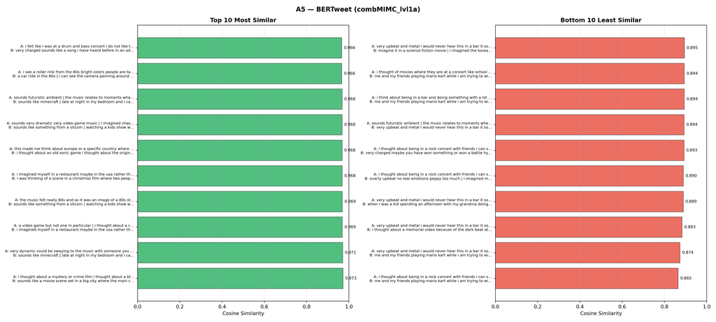

## A6 — paraphrase-MiniLM-L6-v2

**Data**: `combMIMC_lvl1a.csv` | **Preprocessing**: `lvl1a` (light)

`paraphrase-MiniLM-L6-v2` shares the MiniLM-L6 architecture with A7 but is fine-tuned specifically on paraphrase pairs rather than general semantic similarity pairs. Comparing A6 vs A7 (MiniLM) isolates the effect of fine-tuning objective (paraphrase detection vs broad semantic similarity) while holding architecture constant. Comparing A6 vs A9 (paraphrase-mpnet) isolates the architecture effect within the paraphrase objective.

```
A6 — paraphrase-MiniLM-L6-v2  (combMIMC_lvl1a)
```

```
Loaded from cache: (64, 384)
```

```
  Pairs: 2,016  |  skipped — identical: 0  |  short (<5 words): 0  |  same person/cell: 0
```

```
TOP 10:

  [1]  Sim=0.7614  |  ✗ diff clip  ✗ diff context
       Jaz_MED_07 / concert  vs  Jaz_MED_02 / movie
  ── Original A: i imagined myself in a restaurant maybe in the usa rather than the uk a calm evening meal probably at somewhere quite posh | in my mind i could see a jazz bar similar to one you might see in the 1920s there is a couple dancing nearby there is colored woman on stage taking a break fr…
  ── Original B: i was thinking of a scene in a christmas film where two people are in a posh restaurant | a jazz bar or slow dance in a movie scene | i can see a jazz stage the instruments on the side a curtain slowing raising show a beautifully dressed woman who is about to sing | i could imagine …
     Model A:    i myself in a restaurant maybe in the usa rather than the uk a calm evening meal probably at somewhere quite posh endofinput in my mind i see a similar to one you might see in the 1920s there is a couple dancing nearby there is colored woman on stage taking a break from singing the …
     Model B:    i was of a in a christmas where two people are in a posh restaurant endofinput a or slow dance in a endofinput i can see a stage the on the side a curtain slowing raising show a beautifully dressed woman who is about to endofinput i myself in a smokey club just enjoying the vibes en…

  [2]  Sim=0.7488  |  ✗ diff clip  ✓ same context
       Ele_LOW_09 / movie  vs  Met_MED_20 / movie
  ── Original A: sounds like a car chase action scene | driving a flying car in the future and weaving through traffic | it was like a science fiction cyberpunk style space scene music building up to some massive fight | seemed like an adventure film maybe a scene from blade runner | the only thing …
  ── Original B: driving my car really fast and recklessly while just about keeping it on the road | it sounded like anime credits or opening title sequence music | not a movie no idea what weird movie would have that music but a concert sounded like avenge sevenfold the sort of music video i used t…
     Model A:    a car chase action endofinput driving a flying car in the future and weaving through traffic endofinput it was a science fiction cyberpunk style space building up to some massive fight endofinput seemed an adventure maybe a from blade runner endofinput the only thing i can of is a d…
     Model B:    driving my car really fast and recklessly while just about keeping it on the road endofinput it anime credits or opening title sequence endofinput not a no idea what weird have that but a avenge sevenfold the sort of i used to see on kerrang endofinput the resonates my one lost in t…

  [3]  Sim=0.7421  |  ✗ diff clip  ✓ same context
       80s_MED_13 / concert  vs  Ele_MED_19 / concert
  ── Original A: sounds quite magical and whimsical | playing a video game and entering a new zone area | it sounded like an extended version of a 90s console start up sound | i imagined an 80s esque piece abstract at first with a navy blue background fog and cold white blue ambient lighting the las…
  ── Original B: sounds like minecraft | late at night in my bedroom and i can hear the rain come down and tap my bedroom window | sounds like the music youd hear in an indie game | i imagined a track for something taking place on the beach on an overcast blue grey day with cold waters and cold bree…
     Model A:    quite magical and whimsical endofinput a and entering a new zone area endofinput it an extended version of a 90s console start up endofinput i an 80s esque abstract at first with a navy blue background fog and cold white blue ambient lighting the last 13th of the seemed fit for a mu…
     Model B:    minecraft endofinput late at night in my bedroom and i can hear the rain come down and tap my bedroom window endofinput the youd hear in an indie endofinput i a track for something taking place on the beach on an overcast blue grey day with cold waters and cold breezes endofinput th…

  [4]  Sim=0.7390  |  ✗ diff clip  ✓ same context
       Ele_MED_19 / concert  vs  Met_LOW_14 / concert
  ── Original A: sounds like minecraft | late at night in my bedroom and i can hear the rain come down and tap my bedroom window | sounds like the music youd hear in an indie game | i imagined a track for something taking place on the beach on an overcast blue grey day with cold waters and cold bree…
```

[output cut: 45 more lines]

```
BOTTOM 10:

  [1]  Sim=0.1532  |  ✗ diff clip  ✗ diff context
       Met_MED_20 / bar  vs  Jaz_LOW_19 / movie
  ── Original A: i thought of movies where they are at a concert like school of rock or something similar and they are in a mosh pit | i can see myself at the computer desk as a kid opening up spotify to see what avenged sevenfold song was playing whilst doing homework on the computer and talking to…
  ── Original B: i thought about a super mario video game the tune was very similar to the background music in most mario games it made me think about super mario odyssey which was the last mario game that i played | those soccer games where you are picking your teams and setting up formation before…
     Model A:    i of where they are at a school of or something similar and they are in a mosh pit endofinput i can see myself at the computer desk as a kid opening up spotify to see what avenged sevenfold was whilst doing homework on the computer and talking to some friends on facebook at the time…
     Model B:    i about a super mario the tune was very similar to the background in most mario it me about super mario odyssey which was the last mario that i played endofinput those soccer where you are picking your teams and setting up formation before the itself starts endofinput an old set in …

  [2]  Sim=0.1585  |  ✗ diff clip  ✓ same context
       80s_LOW_02 / concert  vs  Ele_MED_20 / concert
  ── Original A: i thought about my dad being in a jazz concert my dad loved jazz and wherever i hear it i think about him this song brought feelings of nostalgia and curiosity | i imagined myself walking into an empty church building where the music instruments are being tested before church servic…
  ── Original B: feels like you are underwater in the sea very calming very relaxing floating around in water | vividly reminds me of a mobile phone ad that i used to get back during covid while watching my favorite streamers | this is the kind of background music you hear when some big tech company…
     Model A:    i about my dad being in a my dad loved and wherever i hear it i about him this brought feelings of nostalgia and curiosity endofinput i myself walking into an empty church building where the are being tested before church service endofinput it did not hit me right away but this me o…
     Model B:    feels you are underwater in the sea very calming very relaxing floating around in water endofinput vividly me of a mobile phone ad that i used to get back during covid while watching my favorite streamers endofinput this is the kind of background you hear when some big tech company …

  [3]  Sim=0.1589  |  ✗ diff clip  ✗ diff context
       Ele_MED_20 / movie  vs  Ele_LOW_09 / videogame
  ── Original A: the thoughts about animals swimming came into my head i saw myself in an aquarium and watching a seal and turtle swim around the music made me pensive as well as i watched the animals swim around | its a scene where something sad has happened and the protagonist is trying to move on…
  ── Original B: very charged sounds like a song i have heard before in an advert about you would not steal a blank feels like its telling you something feels important or like you need to be paying attention | gave much more upbeat energy imagining a car racing through the streets at night with neo…
     Model A:    the thoughts about animals swimming came into my head i saw myself in an aquarium and watching a seal and turtle swim around the me pensive as well as i watched the animals swim around endofinput its a where something sad has happened and the protagonist is trying to move on very so…
     Model B:    very charged a i have heard before in an advert about you not steal a blank feels its telling you something feels important or you need to be paying attention endofinput gave much more upbeat energy a car racing through the streets at night with neon lights around or a high speed ch…

  [4]  Sim=0.1928  |  ✗ diff clip  ✗ diff context
       80s_MED_08 / bar  vs  Ele_MED_20 / concert
  ── Original A: i think about an old 80s movie that takes place in a bar i think about a couple dancing and having a good time this music brings feelings of nostalgia and good times | sounds like a jazz bar but particularly the outdoor seating area everyone is having cocktails or wine and its a war…
```

[output cut: 45 more lines]

```
Saved: /Users/hazelaileenvanderwalle/Library/CloudStorage/OneDrive-Personal/work/study/PhD/_PROJECT/_framedListening_NLP/context-framed-listening/NLP_outputs/model_comparison/pairs_A6_para_minilm.png
```

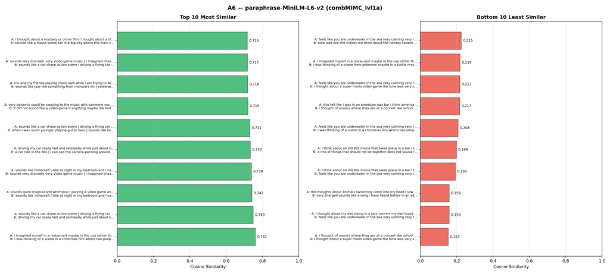

## A7 — all-MiniLM-L6-v2

**Data**: `combMIMC_lvl1a.csv` | **Preprocessing**: `lvl1a` (light)

Fine-tuned for semantic similarity on 1B+ sentence pairs. The embedding space is trained so cosine similarity directly reflects semantic closeness. Running on combMIMC shows whether similarity fine-tuning changes behaviour at document scale vs individual scale (compare A7 vs B7).

```
A7 — all-MiniLM-L6-v2  (combMIMC_lvl1a)
```

```
Loaded from cache: (64, 384)
```

```
  Pairs: 2,016  |  skipped — identical: 0  |  short (<5 words): 0  |  same person/cell: 0
```

```
TOP 10:

  [1]  Sim=0.7548  |  ✗ diff clip  ✓ same context
       80s_LOW_02 / bar  vs  Ele_MED_19 / bar
  ── Original A: kind of sad melancholy not happy or upbeat emotionally charged | made me imagine a high end bar with atmospheric lighting with candles or small lamps on tables cocktails old fashioned etc young bar staff dressed in black and white | reminds me of back in the days my dad used to cons…
  ── Original B: this felt like i was listening to a lofi beats spotify playlist its quite relaxing | a rainy day and a forest | i can see myself in a car as a passenger rain rolling down the windows as we drive on the interstate just outside of boston the sky is gloomy and there is so much fog in t…
     Model A:    kind of sad melancholy not happy or upbeat emotionally charged endofinput me a high end with atmospheric lighting with candles or small lamps on tables cocktails old fashioned etc young staff dressed in black and white endofinput me of back in the days my dad used to constantly kenn…
     Model B:    this felt i was listening to a lofi beats spotify playlist its quite relaxing endofinput a rainy day and a forest endofinput i can see myself in a car as a passenger rain rolling down the windows as we drive on the interstate just outside of boston the sky is gloomy and there is so …

  [2]  Sim=0.7307  |  ✗ diff clip  ✗ diff context
       80s_MED_13 / bar  vs  80s_LOW_06 / concert
  ── Original A: i could only think about sitting on the couch as a kid and this would be the type of song the would play during the credits of an old vhs movie | it sounded like perfect music for an introduction into a movie or video game it was cool and somber | this gave me a disco 80s vibe i ima…
  ── Original B: very bland like lift music or something not something i would specifically think about or remember end credits again | middle aged people at the concert | i imagined walking in a clothing store forever 21 charlotte russe etc and hearing this song blasting from the speakers | it soun…
     Model A:    i only about sitting on the couch as a kid and this be the type of the during the credits of an old vhs endofinput it perfect for an introduction into a or it was cool and somber endofinput this gave me a disco 80s vibe i vibrant colors and afros endofinput a setting not much more c…
     Model B:    very bland lift or something not something i specifically about or end credits again endofinput middle aged people at the endofinput i walking in a clothing store forever 21 charlotte russe etc and hearing this blasting from the speakers endofinput it a bit played in a tv show or a …

  [3]  Sim=0.7209  |  ✗ diff clip  ✓ same context
       80s_LOW_06 / concert  vs  Met_LOW_14 / concert
  ── Original A: very bland like lift music or something not something i would specifically think about or remember end credits again | middle aged people at the concert | i imagined walking in a clothing store forever 21 charlotte russe etc and hearing this song blasting from the speakers | it soun…
  ── Original B: sounds very dramatic very video game music | i imagined chasing someone down some twisting small alleyways | another piece that sounds like boss music in a jrpg or an arcade game that has a time trial on it like a light gun game | long haired metal fans listening to some sort metal …
     Model A:    very bland lift or something not something i specifically about or end credits again endofinput middle aged people at the endofinput i walking in a clothing store forever 21 charlotte russe etc and hearing this blasting from the speakers endofinput it a bit played in a tv show or a …
     Model B:    very dramatic very endofinput i chasing someone down some twisting small alleyways endofinput another that boss in a jrpg or an arcade that has a time trial on it a light gun endofinput long haired fans listening to some sort it felt similar to that through the fire and flames endof…

  [4]  Sim=0.7191  |  ✗ diff clip  ✗ diff context
       Met_LOW_14 / concert  vs  80s_MED_08 / videogame
  ── Original A: sounds very dramatic very video game music | i imagined chasing someone down some twisting small alleyways | another piece that sounds like boss music in a jrpg or an arcade game that has a time trial on it like a light gun game | long haired metal fans listening to some sort metal …
```

[output cut: 45 more lines]

```
BOTTOM 10:

  [1]  Sim=0.1373  |  ✗ diff clip  ✓ same context
       Ele_LOW_14 / videogame  vs  Jaz_MED_02 / videogame
  ── Original A: me and my friends playing mario kart while i am trying to win | it sounds like music from a 90s video game or an arcade machine | pac man some annoying game from the 80s very irritating music a sort of pixelated game | i imagined a pixelated combination scroller moving from left to …
  ── Original B: slow jazz like this makes me think about the holiday season it makes me think of a couple sitting close to a warm fire and staring into it it makes me think of family being together in cozy sweaters and enjoying each others company | choir in a church playing just before the pastor …
     Model A:    me and my friends mario kart while i am trying to win endofinput it from a 90s or an arcade machine endofinput pac man some annoying from the 80s very irritating a sort of pixelated endofinput i a pixelated combination scroller moving from left to right paper mario and fighting mort…
     Model B:    slow this me about the holiday season it me of a couple sitting close to a warm fire and staring into it it me of family being together in cozy sweaters and enjoying each others company endofinput choir in a church just before the pastor starts preaching endofinput a with a in the c…

  [2]  Sim=0.1402  |  ✗ diff clip  ✗ diff context
       Ele_MED_20 / movie  vs  Ele_LOW_09 / videogame
  ── Original A: the thoughts about animals swimming came into my head i saw myself in an aquarium and watching a seal and turtle swim around the music made me pensive as well as i watched the animals swim around | its a scene where something sad has happened and the protagonist is trying to move on…
  ── Original B: very charged sounds like a song i have heard before in an advert about you would not steal a blank feels like its telling you something feels important or like you need to be paying attention | gave much more upbeat energy imagining a car racing through the streets at night with neo…
     Model A:    the thoughts about animals swimming came into my head i saw myself in an aquarium and watching a seal and turtle swim around the me pensive as well as i watched the animals swim around endofinput its a where something sad has happened and the protagonist is trying to move on very so…
     Model B:    very charged a i have heard before in an advert about you not steal a blank feels its telling you something feels important or you need to be paying attention endofinput gave much more upbeat energy a car racing through the streets at night with neon lights around or a high speed ch…

  [3]  Sim=0.1421  |  ✗ diff clip  ✗ diff context
       80s_LOW_06 / movie  vs  Ele_LOW_09 / videogame
  ── Original A: i think about an old sitcom this sounds like it would be in the opening it feels like this song could be about a familial show where there are many happy moments | it sounds like the track of the end credits scene in a happy family movie everyone is shown to be laughing and having f…
  ── Original B: very charged sounds like a song i have heard before in an advert about you would not steal a blank feels like its telling you something feels important or like you need to be paying attention | gave much more upbeat energy imagining a car racing through the streets at night with neo…
     Model A:    i about an old sitcom this it be in the opening it feels this be about a familial show where there are many happy moments endofinput it the track of the end credits in a happy family everyone is shown to be laughing and having fun whilst the credits roll endofinput this me of a 90s …
     Model B:    very charged a i have heard before in an advert about you not steal a blank feels its telling you something feels important or you need to be paying attention endofinput gave much more upbeat energy a car racing through the streets at night with neon lights around or a high speed ch…

  [4]  Sim=0.1451  |  ✗ diff clip  ✓ same context
       Jaz_MED_02 / videogame  vs  Met_LOW_14 / videogame
  ── Original A: slow jazz like this makes me think about the holiday season it makes me think of a couple sitting close to a warm fire and staring into it it makes me think of family being together in cozy sweaters and enjoying each others company | choir in a church playing just before the pastor …
```

[output cut: 45 more lines]

```
Saved: /Users/hazelaileenvanderwalle/Library/CloudStorage/OneDrive-Personal/work/study/PhD/_PROJECT/_framedListening_NLP/context-framed-listening/NLP_outputs/model_comparison/pairs_A7_minilm.png
```

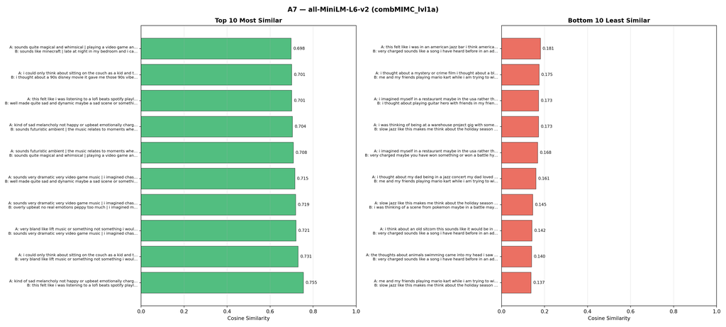

## A8 — all-mpnet-base-v2

**Data**: `combMIMC_lvl1a.csv` | **Preprocessing**: `lvl1a` (light)

```
A8 — all-mpnet-base-v2  (combMIMC_lvl1a)
```

```
Loaded from cache: (64, 768)
```

```
  Pairs: 2,016  |  skipped — identical: 0  |  short (<5 words): 0  |  same person/cell: 0
```

```
TOP 10:

  [1]  Sim=0.8993  |  ✓ same clip  ✗ diff context
       Ele_MED_19 / bar  vs  Ele_MED_19 / concert
  ── Original A: this felt like i was listening to a lofi beats spotify playlist its quite relaxing | a rainy day and a forest | i can see myself in a car as a passenger rain rolling down the windows as we drive on the interstate just outside of boston the sky is gloomy and there is so much fog in t…
  ── Original B: sounds like minecraft | late at night in my bedroom and i can hear the rain come down and tap my bedroom window | sounds like the music youd hear in an indie game | i imagined a track for something taking place on the beach on an overcast blue grey day with cold waters and cold bree…
     Model A:    this felt i was listening to a lofi beats spotify playlist its quite relaxing endofinput a rainy day and a forest endofinput i can see myself in a car as a passenger rain rolling down the windows as we drive on the interstate just outside of boston the sky is gloomy and there is so …
     Model B:    minecraft endofinput late at night in my bedroom and i can hear the rain come down and tap my bedroom window endofinput the youd hear in an indie endofinput i a track for something taking place on the beach on an overcast blue grey day with cold waters and cold breezes endofinput th…

  [2]  Sim=0.8859  |  ✓ same clip  ✗ diff context
       Ele_LOW_14 / concert  vs  Ele_LOW_14 / movie
  ── Original A: i thought about an old sonic game i thought about the original sonic map and sonic running around i thought about the jumping noise that he makes | myself playing contra its a video game in my bedroom sitting on the floor with my back against my bed | a rave lots of strobe lighting …
  ── Original B: i was thinking of being at a warehouse project gig with someone playing old synthy house music it felt fun and enjoyable | i can see undertale on my computer screen i am fighting sans but the music is not quite right i am not running my usual pacifist run so i have to attack him the…
     Model A:    i about an old sonic i about the original sonic map and sonic running around i about the jumping noise that he endofinput myself contra its a in my bedroom sitting on the floor with my back against my bed endofinput a rave lots of strobe lighting and people jumping up and down its a…
     Model B:    i was of being at a warehouse project gig with someone old synthy house it felt fun and enjoyable endofinput i can see undertale on my computer screen i am fighting sans but the is not quite right i am not running my usual pacifist run so i have to attack him the of my hitting him a…

  [3]  Sim=0.8787  |  ✓ same clip  ✗ diff context
       Jaz_LOW_21 / bar  vs  Jaz_LOW_21 / videogame
  ── Original A: phoning some company for help and then being put on hold for a long time while this music plays | it sounds like elevator music or the music you get on a call when you are put on hold would also fit a generic supermarket in a movie | music in some sort of speakeasy if you have ever …
  ── Original B: in a jazz bar again or maybe just a cocktail bar sipping cocktails and having a relaxing time | the song reminds me of goofy old cartoons and makes me think of the looney toons | i think this is what elevator music should be and sound like i enjoyed this very much | instantly the ch…
     Model A:    phoning some company for help and then being put on hold for a long time while this endofinput it elevator or the you get on a call when you are put on hold also fit a generic supermarket in a endofinput in some sort of speakeasy if you have ever watched broad city theres an episode…
     Model B:    in a again or maybe just a cocktail sipping cocktails and having a relaxing time endofinput the me of goofy old cartoons and me of the looney toons endofinput i this is what elevator should be and i enjoyed this very much endofinput instantly the chuckle brothers came tor mind and t…

  [4]  Sim=0.8733  |  ✗ diff clip  ✗ diff context
       Jaz_MED_02 / bar  vs  Ele_MED_19 / concert
  ── Original A: very dynamic could be swaying to the music with someone you care about could be sat with a drink alone thinking about your life something important | again jazz bar in new york city cocktails flowing older clientele everyone nicely dressed atmospheric lighting | i imagined my self w…
```

[output cut: 45 more lines]

```
BOTTOM 10:

  [1]  Sim=0.3373  |  ✗ diff clip  ✗ diff context
       80s_LOW_06 / bar  vs  Ele_LOW_09 / movie
  ── Original A: the music felt really 80s and so it was an image of a 80s style hawaiian bar with hula style decor | the music evokes the feeling of wanting to dance with friends | it made me think about my husband and i miss him wanted to dance and laugh with him just listening to this music sound…
  ── Original B: sounds like a car chase action scene | driving a flying car in the future and weaving through traffic | it was like a science fiction cyberpunk style space scene music building up to some massive fight | seemed like an adventure film maybe a scene from blade runner | the only thing …
     Model A:    the felt really 80s and so it was an of a 80s style hawaiian with hula style decor endofinput the evokes the feeling of wanting to dance with friends endofinput it me about my husband and i miss him wanted to dance and laugh with him just listening to this endofinput i myself and a …
     Model B:    a car chase action endofinput driving a flying car in the future and weaving through traffic endofinput it was a science fiction cyberpunk style space building up to some massive fight endofinput seemed an adventure maybe a from blade runner endofinput the only thing i can of is a d…

  [2]  Sim=0.3971  |  ✗ diff clip  ✓ same context
       Ele_LOW_09 / movie  vs  Jaz_LOW_21 / movie
  ── Original A: sounds like a car chase action scene | driving a flying car in the future and weaving through traffic | it was like a science fiction cyberpunk style space scene music building up to some massive fight | seemed like an adventure film maybe a scene from blade runner | the only thing …
  ── Original B: very peppy like lift music again feels busy like you need to do something maybe walking through a shopping center listening to this in the background | fun supermarket shopping scene in a coming of age movie | reminds me of a tom jerry show i used to watch the sound track playing in…
     Model A:    a car chase action endofinput driving a flying car in the future and weaving through traffic endofinput it was a science fiction cyberpunk style space building up to some massive fight endofinput seemed an adventure maybe a from blade runner endofinput the only thing i can of is a d…
     Model B:    very peppy lift again feels busy you need to do something maybe walking through a shopping center listening to this in the background endofinput fun supermarket shopping in a coming of age endofinput me of a tom jerry show i used to watch the track in the background while tom and je…

  [3]  Sim=0.4029  |  ✗ diff clip  ✗ diff context
       Jaz_MED_07 / concert  vs  Ele_LOW_09 / movie
  ── Original A: i imagined myself in a restaurant maybe in the usa rather than the uk a calm evening meal probably at somewhere quite posh | in my mind i could see a jazz bar similar to one you might see in the 1920s there is a couple dancing nearby there is colored woman on stage taking a break fr…
  ── Original B: sounds like a car chase action scene | driving a flying car in the future and weaving through traffic | it was like a science fiction cyberpunk style space scene music building up to some massive fight | seemed like an adventure film maybe a scene from blade runner | the only thing …
     Model A:    i myself in a restaurant maybe in the usa rather than the uk a calm evening meal probably at somewhere quite posh endofinput in my mind i see a similar to one you might see in the 1920s there is a couple dancing nearby there is colored woman on stage taking a break from singing the …
     Model B:    a car chase action endofinput driving a flying car in the future and weaving through traffic endofinput it was a science fiction cyberpunk style space building up to some massive fight endofinput seemed an adventure maybe a from blade runner endofinput the only thing i can of is a d…

  [4]  Sim=0.4157  |  ✗ diff clip  ✗ diff context
       Ele_LOW_09 / movie  vs  Jaz_LOW_21 / videogame
  ── Original A: sounds like a car chase action scene | driving a flying car in the future and weaving through traffic | it was like a science fiction cyberpunk style space scene music building up to some massive fight | seemed like an adventure film maybe a scene from blade runner | the only thing …
```

[output cut: 45 more lines]

```
Saved: /Users/hazelaileenvanderwalle/Library/CloudStorage/OneDrive-Personal/work/study/PhD/_PROJECT/_framedListening_NLP/context-framed-listening/NLP_outputs/model_comparison/pairs_A8_mpnet.png
```

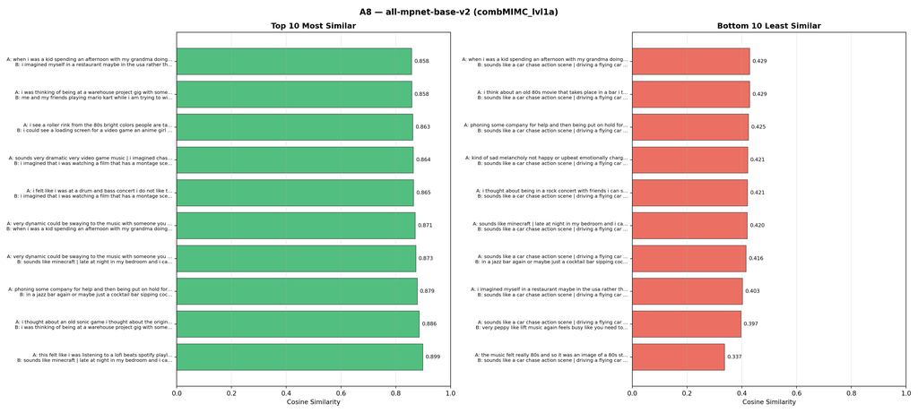

## A9 — paraphrase-mpnet-base-v2

**Data**: `combMIMC_lvl1a.csv` | **Preprocessing**: `lvl1a` (light)

Fine-tuned for paraphrase detection — identifying when two sentences express the same meaning in different words. Closest analogue to the MIMC task objective.

```
A9 — paraphrase-mpnet-base-v2  (combMIMC_lvl1a)
```

```
Loaded from cache: (64, 768)
```

```
  Pairs: 2,016  |  skipped — identical: 0  |  short (<5 words): 0  |  same person/cell: 0
```

```
TOP 10:

  [1]  Sim=0.8745  |  ✓ same clip  ✗ diff context
       80s_LOW_02 / movie  vs  80s_LOW_02 / videogame
  ── Original A: sounds like a movie scene set in a big city where the main character is depressed or wandering the streets at night | i could see a camera panning around a raining city somewhere hidden along the street is a bar where a detective is having a drink hes down on his luck and think the …
  ── Original B: sounds very mysterious | breaking up with someone who i have been dating for a long time and then they start crying | it was a bit noir esque like a dark detective movie set in the 40s or 50s in the us | the music felt like a game where you play as a detective the game was very noir…
     Model A:    a set in a big city where the main character is depressed or wandering the streets at night endofinput i see a camera panning around a raining city somewhere hidden along the street is a where a detective is having a drink hes down on his luck and the culprit is going to get away bu…
     Model B:    very mysterious endofinput breaking up with someone who i have been dating for a long time and then they start crying endofinput it was a bit noir esque a dark detective set in the 40s or 50s in the us endofinput the felt a where you as a detective the was very noir and black and wh…

  [2]  Sim=0.8612  |  ✗ diff clip  ✓ same context
       80s_LOW_02 / bar  vs  Jaz_MED_02 / bar
  ── Original A: kind of sad melancholy not happy or upbeat emotionally charged | made me imagine a high end bar with atmospheric lighting with candles or small lamps on tables cocktails old fashioned etc young bar staff dressed in black and white | reminds me of back in the days my dad used to cons…
  ── Original B: very dynamic could be swaying to the music with someone you care about could be sat with a drink alone thinking about your life something important | again jazz bar in new york city cocktails flowing older clientele everyone nicely dressed atmospheric lighting | i imagined my self w…
     Model A:    kind of sad melancholy not happy or upbeat emotionally charged endofinput me a high end with atmospheric lighting with candles or small lamps on tables cocktails old fashioned etc young staff dressed in black and white endofinput me of back in the days my dad used to constantly kenn…
     Model B:    very dynamic be swaying to the with someone you care about be sat with a drink alone about your life something important endofinput again in new york city cocktails flowing older clientele everyone nicely dressed atmospheric lighting endofinput i my self watching a live and feeling …

  [3]  Sim=0.8474  |  ✓ same clip  ✗ diff context
       Ele_MED_19 / bar  vs  Ele_MED_19 / movie
  ── Original A: this felt like i was listening to a lofi beats spotify playlist its quite relaxing | a rainy day and a forest | i can see myself in a car as a passenger rain rolling down the windows as we drive on the interstate just outside of boston the sky is gloomy and there is so much fog in t…
  ── Original B: well made quite sad and dynamic maybe a sad scene or something is being revealed doing something important maybe walking in the rain or going to do something you should not be | initially imagined it to be a piece playing over a sad moment of the movie however as the beat was added …
     Model A:    this felt i was listening to a lofi beats spotify playlist its quite relaxing endofinput a rainy day and a forest endofinput i can see myself in a car as a passenger rain rolling down the windows as we drive on the interstate just outside of boston the sky is gloomy and there is so …
     Model B:    well quite sad and dynamic maybe a sad or something is being revealed doing something important maybe walking in the rain or going to do something you should not be endofinput initially it to be a over a sad moment of the however as the beat was added it fit more with a coming of ag…

  [4]  Sim=0.8442  |  ✗ diff clip  ✗ diff context
       Jaz_MED_07 / concert  vs  Jaz_MED_02 / movie
  ── Original A: i imagined myself in a restaurant maybe in the usa rather than the uk a calm evening meal probably at somewhere quite posh | in my mind i could see a jazz bar similar to one you might see in the 1920s there is a couple dancing nearby there is colored woman on stage taking a break fr…
```

[output cut: 45 more lines]

```
BOTTOM 10:

  [1]  Sim=0.3878  |  ✗ diff clip  ✗ diff context
       Met_LOW_09 / concert  vs  Jaz_LOW_21 / videogame
  ── Original A: very heavy rock not for me somewhere that i do not belong did not enjoy | middle aged men who ride motorbikes with long grey beards mosh pits dark night time concert loud headbanging | i imagined my self watching a bunch of heavy metal songs with my favorite headset on | it felt lik…
  ── Original B: in a jazz bar again or maybe just a cocktail bar sipping cocktails and having a relaxing time | the song reminds me of goofy old cartoons and makes me think of the looney toons | i think this is what elevator music should be and sound like i enjoyed this very much | instantly the ch…
     Model A:    very heavy not for me somewhere that i do not belong did not enjoy endofinput middle aged men who ride motorbikes with long grey beards mosh pits dark night time loud headbanging endofinput i my self watching a bunch of heavy with my favorite headset on endofinput it felt i was at a…
     Model B:    in a again or maybe just a cocktail sipping cocktails and having a relaxing time endofinput the me of goofy old cartoons and me of the looney toons endofinput i this is what elevator should be and i enjoyed this very much endofinput instantly the chuckle brothers came tor mind and t…

  [2]  Sim=0.3885  |  ✗ diff clip  ✗ diff context
       Met_LOW_14 / movie  vs  Jaz_LOW_21 / videogame
  ── Original A: a mix of things that should not be together does not sound right or meshed well to me too much going on not sure what part of a movie it would fit sounded confusing | the clip reminds me of a popular jason statham action movie i watched a few years ago the main actor being chased by…
  ── Original B: in a jazz bar again or maybe just a cocktail bar sipping cocktails and having a relaxing time | the song reminds me of goofy old cartoons and makes me think of the looney toons | i think this is what elevator music should be and sound like i enjoyed this very much | instantly the ch…
     Model A:    a mix of things that should not be together does not right or meshed well to me too much going on not sure what part of a it fit confusing endofinput the me of a popular jason statham action i watched a few years ago the main actor being chased by the bad guys or the cops endofinput…
     Model B:    in a again or maybe just a cocktail sipping cocktails and having a relaxing time endofinput the me of goofy old cartoons and me of the looney toons endofinput i this is what elevator should be and i enjoyed this very much endofinput instantly the chuckle brothers came tor mind and t…

  [3]  Sim=0.4032  |  ✗ diff clip  ✗ diff context
       Met_MED_20 / concert  vs  Jaz_LOW_21 / videogame
  ── Original A: i thought about being in a rock concert with friends i can see myself looking to my right and left and being in the middle of a huge body of people i can see me and my friends jumping up and down and enjoying the guitar solo | one of those white people music concerts where the artis…
  ── Original B: in a jazz bar again or maybe just a cocktail bar sipping cocktails and having a relaxing time | the song reminds me of goofy old cartoons and makes me think of the looney toons | i think this is what elevator music should be and sound like i enjoyed this very much | instantly the ch…
     Model A:    i about being in a with friends i can see myself looking to my right and left and being in the middle of a huge body of people i can see me and my friends jumping up and down and enjoying the solo endofinput one of those white people where the artist a and they go wild but its a nic…
     Model B:    in a again or maybe just a cocktail sipping cocktails and having a relaxing time endofinput the me of goofy old cartoons and me of the looney toons endofinput i this is what elevator should be and i enjoyed this very much endofinput instantly the chuckle brothers came tor mind and t…

  [4]  Sim=0.4188  |  ✗ diff clip  ✓ same context
       Jaz_LOW_21 / videogame  vs  Met_LOW_09 / videogame
  ── Original A: in a jazz bar again or maybe just a cocktail bar sipping cocktails and having a relaxing time | the song reminds me of goofy old cartoons and makes me think of the looney toons | i think this is what elevator music should be and sound like i enjoyed this very much | instantly the ch…
```

[output cut: 45 more lines]

```
Saved: /Users/hazelaileenvanderwalle/Library/CloudStorage/OneDrive-Personal/work/study/PhD/_PROJECT/_framedListening_NLP/context-framed-listening/NLP_outputs/model_comparison/pairs_A9_para.png
```

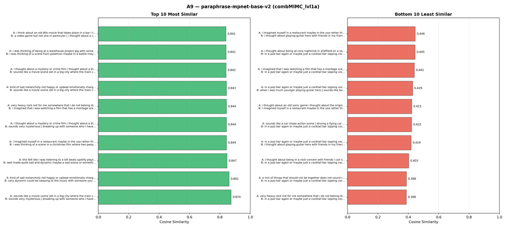

## Group A — Cross-Model Comparison

All Group A models share the same 64-document dataset (or a 64-document dataset with the same row ordering), so pair indices are consistent. TF-IDF is used as the reference for the side-by-side heatmap as it is the most interpretable baseline.

```
=================================================================
Group A — Rank Correlation of Pair Similarity Orderings
=================================================================
Saved: /Users/hazelaileenvanderwalle/Library/CloudStorage/OneDrive-Personal/work/study/PhD/_PROJECT/_framedListening_NLP/context-framed-listening/NLP_outputs/model_comparison/groupA_rank_correlation.png

RANK CORRELATION MATRIX — Group A
  (Pearson r on ranked pairwise similarity scores)
                                  TF-IDF       W2V-lvl2a       W2V-lvl1a            BERT        BERTweet     para-MiniLM          MiniLM           mpnet      para-mpnet
  ----------------------------------------------------------------------------------------------------------------------------------------------------------------------
  TF-IDF                          1.000*          0.701*          0.604*          0.554*          0.175*          0.324*          0.282*          0.303*          0.556*
  W2V-lvl2a                                       1.000*          0.891*          0.705*          0.135*          0.328*          0.335*          0.436*          0.672*
  W2V-lvl1a                                                       1.000*          0.703*          0.147*          0.235*          0.243*          0.371*          0.596*
  BERT                                                                            1.000*          0.264*          0.266*          0.306*          0.540*          0.651*
  BERTweet                                                                                        1.000*          0.252*          0.212*          0.224*          0.231*
  para-MiniLM                                                                                                     1.000*          0.765*          0.304*          0.439*
  MiniLM                                                                                                                          1.000*          0.338*          0.457*
  mpnet                                                                                                                                           1.000*          0.630*
  para-mpnet                                                                                                                                                      1.000*
  * p < .05
Saved: /Users/hazelaileenvanderwalle/Library/CloudStorage/OneDrive-Personal/work/study/PhD/_PROJECT/_framedListening_NLP/context-framed-listening/NLP_outputs/model_comparison/groupA_jaccard_top.png
Saved: /Users/hazelaileenvanderwalle/Library/CloudStorage/OneDrive-Personal/work/study/PhD/_PROJECT/_framedListening_NLP/context-framed-listening/NLP_outputs/model_comparison/groupA_jaccard_bottom.png
Saved: /Users/hazelaileenvanderwalle/Library/CloudStorage/OneDrive-Personal/work/study/PhD/_PROJECT/_framedListening_NLP/context-framed-listening/NLP_outputs/model_comparison/groupA_distributions.png

SUMMARY STATISTICS — Group A
Model                      Mean   Median       SD      Min      Max
------------------------------------------------------------------
  TF-IDF                 0.1257   0.1212   0.0360   0.0501   0.3213
  W2V-lvl2a              0.9196   0.9233   0.0260   0.8114   0.9782
  W2V-lvl1a              0.9652   0.9670   0.0118   0.9117   0.9882
  BERT                   0.9611   0.9625   0.0104   0.9095   0.9834
  BERTweet               0.9427   0.9446   0.0131   0.8649   0.9725
  para-MiniLM            0.4699   0.4662   0.1020   0.1532   0.7614
  MiniLM                 0.4316   0.4315   0.1073   0.1373   0.7548
  mpnet                  0.7045   0.7142   0.0790   0.3373   0.8993
  para-mpnet             0.6561   0.6571   0.0764   0.3878   0.8745
Saved: /Users/hazelaileenvanderwalle/Library/CloudStorage/OneDrive-Personal/work/study/PhD/_PROJECT/_framedListening_NLP/context-framed-listening/NLP_outputs/model_comparison/groupA_cross_model_heatmap.png

CROSS-MODEL SCORES — Group A (reference: TF-IDF top/bottom 10 pairs)
================================================================================

```

[output cut: 244 more lines]

```
    mpnet                          0.7837
    para-mpnet                     0.7051

  [BOTTOM]
  A: the music felt really 80s and so it was an image of a 80s style hawaiian bar with hula style decor | the music evokes the feeling of wanting to dance with friends | it made me think about my husband and i miss him wanted to dance and laugh with him just listening to this music sound | i imagine…
  B: when i was much younger playing guitar hero | sounds like boss fight music straight out a jrpg like yakuza | a heavy metal guitar hero game playing guitar hero on the wii | i could imagine the screen for guitar hero on display and someone playing with their friend | this music evokes the sense …
    TF-IDF                         0.0598
    W2V-lvl2a                      0.8279
    W2V-lvl1a                      0.9262
    BERT                           0.9284
    BERTweet                       0.9442
    para-MiniLM                    0.3312
    MiniLM                         0.3383
    mpnet                          0.4782
    para-mpnet                     0.5558
```

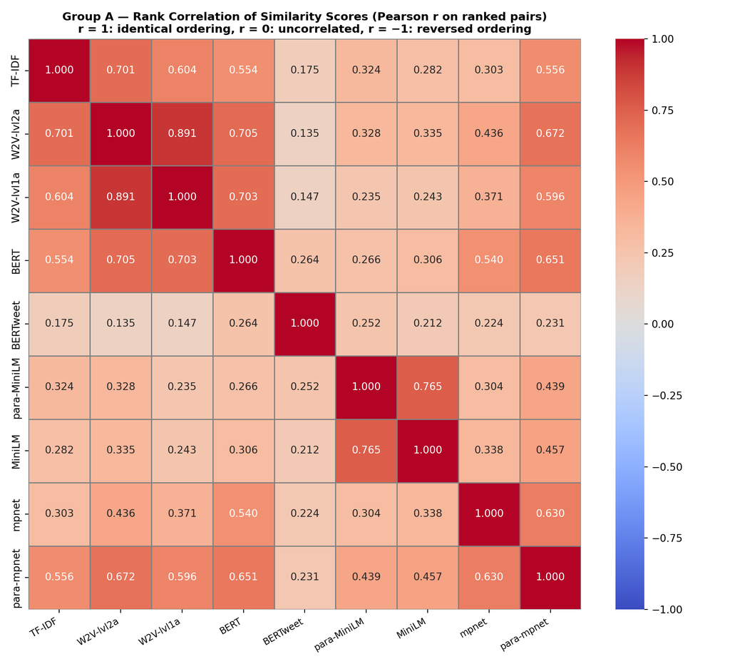

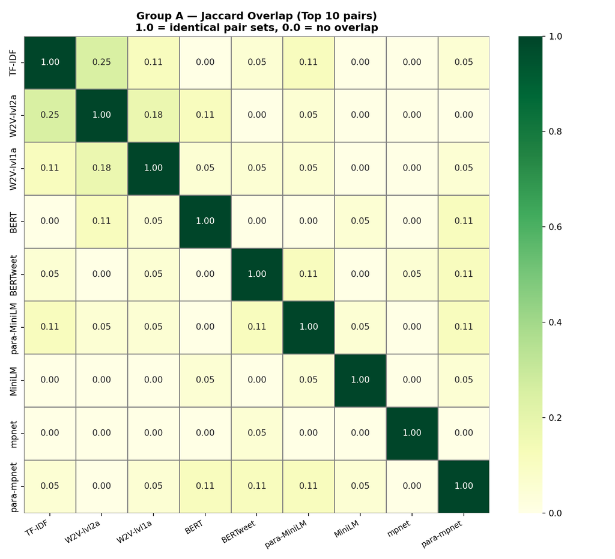

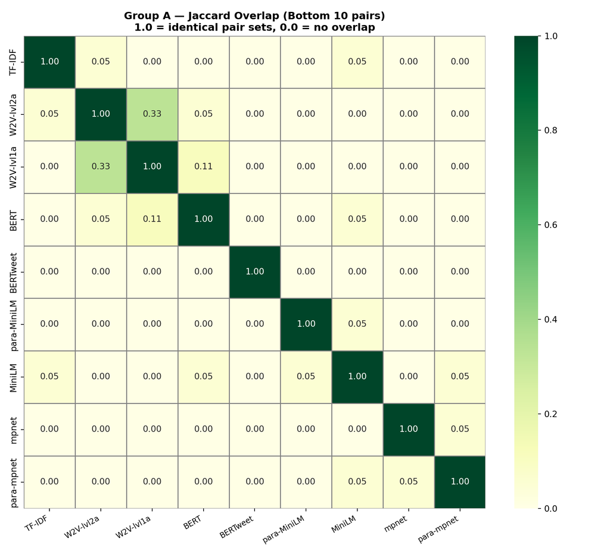

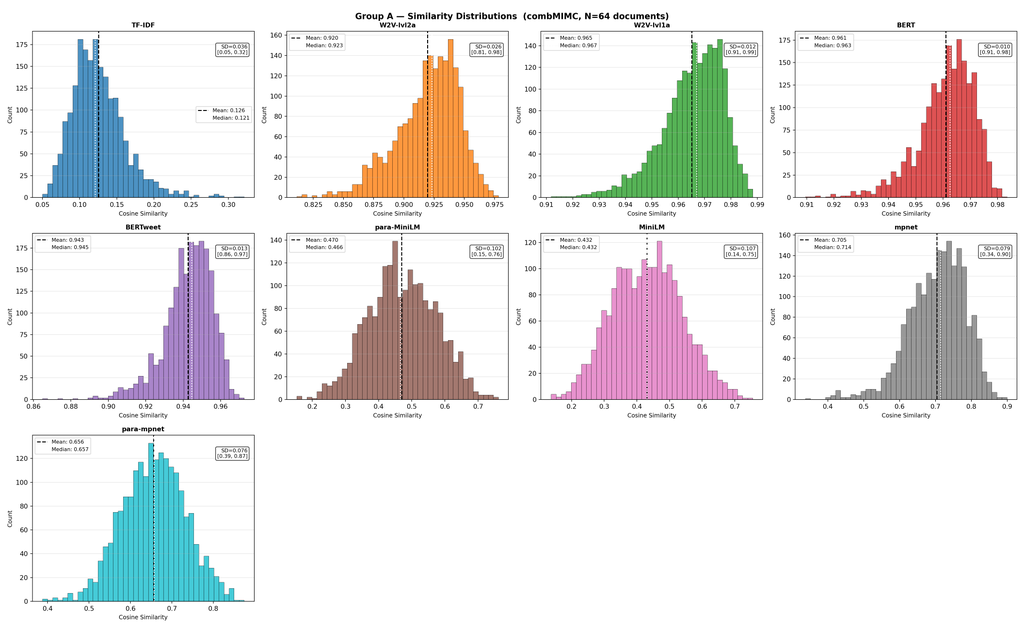

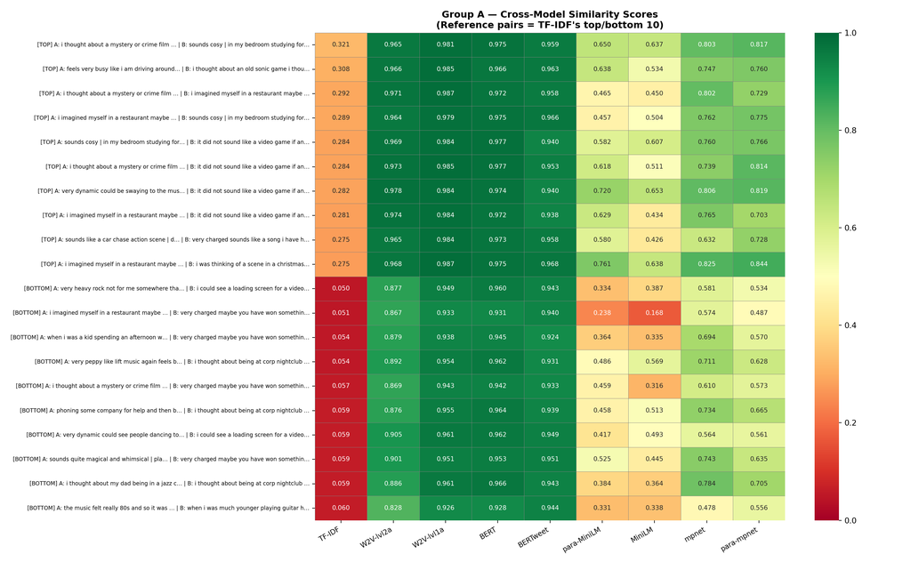

# Group B — Individual MIMC (N = all responses)

## B1 — TF-IDF

**Data**: `dataMIMC_preprocessed.csv` | **Preprocessing**: `lvl2a` (aggressive)

TF-IDF on individual ~10–50 word texts. Most pairs will share zero or very few words, producing near-uniform low similarity. This demonstrates empirically why TF-IDF is unsuitable for individual-level analysis.

```
B1 — TF-IDF  (individual, lvl2a)
```

```
  Pairs: 1,764,380  |  skipped — identical: 11  |  short (<5 words): 128,094  |  same person/cell: 0
```

```
TOP 10:

  [1]  Sim=1.0000  |  ✗ diff clip  ✓ same context
       Jaz_LOW_19 / videogame  vs  Met_MED_19 / videogame
  ── Original A: it sounds like the music from a car racing game
  ── Original B: i imagined a car racing game for this scene
     Model A:    car racing
     Model B:    car racing

  [2]  Sim=1.0000  |  ✓ same clip  ✗ diff context
       Jaz_MED_07 / videogame  vs  Jaz_MED_07 / movie
  ── Original A: i am watching a romantic movie from the 90s and this is playing
  ── Original B: watching a romantic scene on a movie
     Model A:    watch romantic
     Model B:    watch romantic

  [3]  Sim=1.0000  |  ✗ diff clip  ✓ same context
       Met_LOW_09 / concert  vs  Jaz_LOW_19 / concert
  ── Original A: its an energetic rock song with a strong beat and a powerful electric guitar
  ── Original B: it sounded like a energetic rock song with a strong beat and a powerful electric guitar
     Model A:    energetic strong beat powerful electric
     Model B:    energetic strong beat powerful electric

  [4]  Sim=1.0000  |  ✗ diff clip  ✗ diff context
       Jaz_LOW_19 / bar  vs  80s_LOW_02 / movie
  ── Original A: when am in a restaurant
  ── Original B: sounded like music at a bar restaurant
     Model A:    restaurant
     Model B:    restaurant

  [5]  Sim=1.0000  |  ✗ diff clip  ✗ diff context
       Ele_LOW_09 / movie  vs  80s_LOW_02 / videogame
  ── Original A: sounds like a song that plays for the credits at the end of a movie
  ── Original B: imagined end credits of a game
     Model A:    credit end
     Model B:    end credit

  [6]  Sim=1.0000  |  ✗ diff clip  ✗ diff context
       Ele_LOW_09 / movie  vs  80s_MED_08 / concert
  ── Original A: sounds like a song that plays for the credits at the end of a movie
```

[output cut: 16 more lines]

```
     Model B:    end credit

  [9]  Sim=1.0000  |  ✗ diff clip  ✗ diff context
       Met_LOW_09 / movie  vs  Met_MED_20 / concert
  ── Original A: in a band when i was watching a movie
  ── Original B: i thought of watching movie with that sound
     Model A:    watch
     Model B:    watch

  [10]  Sim=1.0000  |  ✗ diff clip  ✓ same context
       Met_MED_20 / videogame  vs  Met_MED_19 / videogame
  ── Original A: sounds like it would be in guitar hero
  ── Original B: i am playing guitar hero to this song i am rocking out
     Model A:    hero
     Model B:    hero
```

```
BOTTOM 10:

  [1]  Sim=0.0000  |  ✗ diff clip  ✗ diff context
       80s_MED_08 / videogame  vs  Met_MED_20 / bar
  ── Original A: while playing swede video games with my friends
  ── Original B: i would say it is still an instrumental music mostly presented in a stage with live audience
     Model A:    swede friend
     Model B:    say still mostly present stage live audience

  [2]  Sim=0.0000  |  ✗ diff clip  ✗ diff context
       80s_MED_08 / videogame  vs  Met_MED_19 / concert
  ── Original A: while playing swede video games with my friends
  ── Original B: i pictured music performed live on stage
     Model A:    swede friend
     Model B:    perform live stage

  [3]  Sim=0.0000  |  ✗ diff clip  ✗ diff context
       80s_MED_08 / videogame  vs  Jaz_LOW_19 / bar
  ── Original A: while playing swede video games with my friends
  ── Original B: the beginning had a sinister vibe it reminded me of bowser castle in mario cart however the jazz music brought a happier tone vibe
     Model A:    swede friend
     Model B:    beginning sinister vibe bowser castle mario cart however bring happier tone vibe

  [4]  Sim=0.0000  |  ✗ diff clip  ✗ diff context
       80s_MED_08 / videogame  vs  Ele_LOW_14 / movie
  ── Original A: while playing swede video games with my friends
  ── Original B: reminded me of the matrix or blade runner someone running down the street in pursuit of something someone technological and modern devices
     Model A:    swede friend
     Model B:    matrix blade runner someone run street pursuit something someone technological modern device

  [5]  Sim=0.0000  |  ✗ diff clip  ✓ same context
       80s_MED_08 / videogame  vs  Jaz_LOW_21 / videogame
  ── Original A: while playing swede video games with my friends
  ── Original B: instantly the chuckle brothers came tor mind and then a cat cafe which is white and has cats everywhere light hearted cheery vibe
     Model A:    swede friend
     Model B:    instantly chuckle brother come tor mind cat cafe white cat everywhere light hearted cheery vibe

  [6]  Sim=0.0000  |  ✗ diff clip  ✗ diff context
       80s_MED_08 / videogame  vs  Met_LOW_09 / movie
  ── Original A: while playing swede video games with my friends
```

[output cut: 16 more lines]

```
     Model B:    rave tightly pack surround people lot light ray stage go crowd overwhelm uncomfortable

  [9]  Sim=0.0000  |  ✗ diff clip  ✗ diff context
       80s_MED_08 / videogame  vs  Ele_MED_19 / bar
  ── Original A: while playing swede video games with my friends
  ── Original B: i instantly imagined myself sat in a bar by myself feeling pretty down and then when the beat dropped i imagined locking eyes with someone this music feels like meeting someone special for the first time
     Model A:    swede friend
     Model B:    instantly sit feel pretty beat drop lock eye someone feel meet someone special first time

  [10]  Sim=0.0000  |  ✗ diff clip  ✗ diff context
       Ele_MED_20 / movie  vs  Met_LOW_09 / videogame
  ── Original A: i imagined a documentary mostly about fun facts or historic information
  ── Original B: i imagined a wrestling show
     Model A:    documentary mostly fun fact historic information
     Model B:    wrestling show
```

```
Saved: /Users/hazelaileenvanderwalle/Library/CloudStorage/OneDrive-Personal/work/study/PhD/_PROJECT/_framedListening_NLP/context-framed-listening/NLP_outputs/model_comparison/pairs_B1_tfidf.png
```

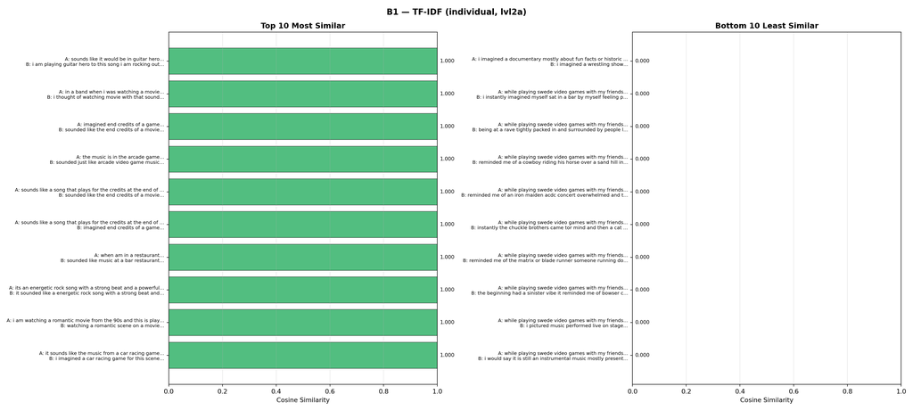

## B2 — Word2Vec (`lvl2a`)

**Data**: `dataMIMC_preprocessed.csv` | **Preprocessing**: `lvl2a` (aggressive)

Word2Vec on individual texts with aggressive preprocessing. Short texts provide fewer words to average, making the mean vector less stable and representative.

```
B2 — Word2Vec lvl2a  (individual)
```

```
  Pairs: 1,764,380  |  skipped — identical: 11  |  short (<5 words): 128,094  |  same person/cell: 0
```

```
TOP 10:

  [1]  Sim=1.0000  |  ✗ diff clip  ✗ diff context
       Met_MED_19 / bar  vs  Ele_LOW_14 / movie
  ── Original A: the music is in the arcade game
  ── Original B: sounded just like arcade video game music
     Model A:    arcade
     Model B:    arcade

  [2]  Sim=1.0000  |  ✗ diff clip  ✗ diff context
       Jaz_LOW_19 / bar  vs  80s_LOW_02 / movie
  ── Original A: when am in a restaurant
  ── Original B: sounded like music at a bar restaurant
     Model A:    restaurant
     Model B:    restaurant

  [3]  Sim=1.0000  |  ✗ diff clip  ✓ same context
       Met_MED_20 / videogame  vs  Met_MED_19 / videogame
  ── Original A: sounds like it would be in guitar hero
  ── Original B: i am playing guitar hero to this song i am rocking out
     Model A:    hero
     Model B:    hero

  [4]  Sim=1.0000  |  ✗ diff clip  ✓ same context
       Met_LOW_09 / concert  vs  Jaz_LOW_19 / concert
  ── Original A: its an energetic rock song with a strong beat and a powerful electric guitar
  ── Original B: it sounded like a energetic rock song with a strong beat and a powerful electric guitar
     Model A:    energetic strong beat powerful electric
     Model B:    energetic strong beat powerful electric

  [5]  Sim=1.0000  |  ✗ diff clip  ✓ same context
       Jaz_LOW_19 / videogame  vs  Met_MED_19 / videogame
  ── Original A: it sounds like the music from a car racing game
  ── Original B: i imagined a car racing game for this scene
     Model A:    car racing
     Model B:    car racing

  [6]  Sim=1.0000  |  ✗ diff clip  ✗ diff context
       Met_LOW_09 / movie  vs  Met_MED_20 / concert
  ── Original A: in a band when i was watching a movie
```

[output cut: 16 more lines]

```
     Model B:    end credit

  [9]  Sim=1.0000  |  ✗ diff clip  ✗ diff context
       Ele_LOW_09 / movie  vs  80s_LOW_02 / videogame
  ── Original A: sounds like a song that plays for the credits at the end of a movie
  ── Original B: imagined end credits of a game
     Model A:    credit end
     Model B:    end credit

  [10]  Sim=1.0000  |  ✗ diff clip  ✗ diff context
       Ele_LOW_09 / movie  vs  80s_MED_08 / concert
  ── Original A: sounds like a song that plays for the credits at the end of a movie
  ── Original B: sounded like the end credits of a movie
     Model A:    credit end
     Model B:    end credit
```

```
BOTTOM 10:

  [1]  Sim=-0.1265  |  ✓ same clip  ✗ diff context
       Ele_LOW_14 / videogame  vs  Ele_LOW_14 / concert
  ── Original A: playing a gta and minecraft game
  ── Original B: the music put me in mind of an before school
     Model A:    gta minecraft
     Model B:    put mind school

  [2]  Sim=-0.1215  |  ✗ diff clip  ✗ diff context
       Ele_MED_20 / concert  vs  Ele_LOW_14 / videogame
  ── Original A: sounds like a curtain raising track at a concert
  ── Original B: playing a gta and minecraft game
     Model A:    curtain raise track
     Model B:    gta minecraft

  [3]  Sim=-0.1205  |  ✗ diff clip  ✗ diff context
       Ele_LOW_14 / videogame  vs  80s_MED_08 / concert
  ── Original A: playing a gta and minecraft game
  ── Original B: reminds me of my graduation day
     Model A:    gta minecraft
     Model B:    graduation day

  [4]  Sim=-0.1204  |  ✗ diff clip  ✗ diff context
       Jaz_LOW_21 / movie  vs  Ele_LOW_14 / videogame
  ── Original A: i imagined like i was in a farm
  ── Original B: playing a gta and minecraft game
     Model A:    farm
     Model B:    gta minecraft

  [5]  Sim=-0.1168  |  ✗ diff clip  ✗ diff context
       Ele_LOW_14 / videogame  vs  Met_MED_19 / concert
  ── Original A: playing a gta and minecraft game
  ── Original B: rock music at a concert like yungblud uplifting and energetic music at a rock concert
     Model A:    gta minecraft
     Model B:    yungblud uplifting energetic

  [6]  Sim=-0.1150  |  ✗ diff clip  ✗ diff context
       Ele_LOW_09 / concert  vs  Met_LOW_14 / videogame
  ── Original A: it made me think remember a few raves i have been to such as dreamland and boomtown
```

[output cut: 16 more lines]

```
     Model B:    gta minecraft

  [9]  Sim=-0.1136  |  ✗ diff clip  ✗ diff context
       80s_LOW_02 / bar  vs  Ele_LOW_14 / videogame
  ── Original A: i imagined walking slowly through a peaceful garden while listening to the sounds
  ── Original B: playing a gta and minecraft game
     Model A:    walk slowly peaceful garden listen
     Model B:    gta minecraft

  [10]  Sim=-0.1127  |  ✗ diff clip  ✓ same context
       Ele_LOW_14 / videogame  vs  Ele_MED_20 / videogame
  ── Original A: playing a gta and minecraft game
  ── Original B: transition music at a concert
     Model A:    gta minecraft
     Model B:    transition
```

```
Saved: /Users/hazelaileenvanderwalle/Library/CloudStorage/OneDrive-Personal/work/study/PhD/_PROJECT/_framedListening_NLP/context-framed-listening/NLP_outputs/model_comparison/pairs_B2_w2v_lvl2a.png
```

[figure not shown]

## B3 — Word2Vec (`lvl1a`)

**Data**: `dataMIMC_preprocessed.csv` | **Preprocessing**: `lvl1a` (light)

Word2Vec on light-preprocessed individual texts. Comparing B2 vs B3 shows the preprocessing effect at the individual level. Comparing B3 vs B4 (BERT) isolates contextualisation on identical individual-level inputs.

```
B3 — Word2Vec lvl1a  (individual)
```

```
  Pairs: 1,764,380  |  skipped — identical: 11  |  short (<5 words): 128,094  |  same person/cell: 0
```

```
TOP 10:

  [1]  Sim=0.9658  |  ✗ diff clip  ✗ diff context
       80s_LOW_02 / videogame  vs  80s_MED_08 / concert
  ── Original A: imagined end credits of a game
  ── Original B: sounded like the end credits of a movie
     Model A:    end credits of a
     Model B:    the end credits of a

  [2]  Sim=0.9528  |  ✗ diff clip  ✓ same context
       Met_LOW_09 / concert  vs  Jaz_LOW_19 / concert
  ── Original A: its an energetic rock song with a strong beat and a powerful electric guitar
  ── Original B: it sounded like a energetic rock song with a strong beat and a powerful electric guitar
     Model A:    its an energetic with a strong beat and a powerful electric
     Model B:    it a energetic with a strong beat and a powerful electric

  [3]  Sim=0.9443  |  ✗ diff clip  ✗ diff context
       Met_MED_20 / concert  vs  Met_MED_19 / movie
  ── Original A: my mind instantly went to avenged sevenfold they were one of my favorite bands growing up and this sounded exactly like something i have heard before the guitar solos really gave me an uplifting mood and made me sit up in my chair i love music like this especially while working out …
  ── Original B: my mind instantly went back to avenged sevenfold from a previous song in this study i love this kind of music and instantly got me hyped up more i envisioned myself in my car listening to something like this after work and jamming out to the drums especially
     Model A:    my mind instantly went to avenged sevenfold they were one of my favorite bands growing up and this exactly something i have heard before the solos really gave me an uplifting mood and me sit up in my chair i love this especially while working out or driving in the afternoons
     Model B:    my mind instantly went back to avenged sevenfold from a previous in this study i love this kind of and instantly got me hyped up more i envisioned myself in my car listening to something this after work and jamming out to the especially

  [4]  Sim=0.9431  |  ✗ diff clip  ✗ diff context
       Met_LOW_14 / bar  vs  Met_MED_20 / concert
  ── Original A: my exboyfriends step dad loved the band kiss and he would always play their music in his room and that is exactly what i thought about when i heard this song playing it brought some sad memories because our relationship did not end well
  ── Original B: this sounded kind of like the last one so it made me think about the same thing someone i used to know that was in love with the band kiss part of those memories were not good so this just made me sad again i thought about sitting in the living room and hearing him jamming in his ro…
     Model A:    my exboyfriends step dad loved the kiss and he always their in his room and that is exactly what i about when i heard this it brought some sad because our relationship did not end well
     Model B:    this kind of the last one so it me about the same thing someone i used to know that was in love with the kiss part of those were not good so this just me sad again i about sitting in the living room and hearing him jamming in his room

  [5]  Sim=0.9368  |  ✗ diff clip  ✗ diff context
       Met_MED_19 / videogame  vs  Ele_LOW_09 / movie
  ── Original A: the context was video game but i think even without that i would have pictured games because it sounded very typical of an older action fighting type game or maybe a science fiction racing game or something i really liked the music and imagined what kind of game it would suit as a s…
  ── Original B: it said movie so i imagined what type of movie it would fit as a soundtrack and figured probably action or science fiction but then it also gave me strong video game vibes so i started picturing that a bit too i have been very interested in terminator lately so i imagined parts of t…
     Model A:    the context was but i even without that i have because it very typical of an older action fighting type or maybe a science fiction racing or something i really liked the and what kind of it suit as a soundtrack based on i have played in the past and my modest experience as a hobby d…
     Model B:    it said so i what type of it fit as a soundtrack and figured probably action or science fiction but then it also gave me strong vibes so i started that a bit too i have been very interested in terminator lately so i parts of that and the based on it especially the retro ones althoug…

  [6]  Sim=0.9336  |  ✗ diff clip  ✗ diff context
       Ele_LOW_14 / movie  vs  Ele_LOW_09 / bar
  ── Original A: i can see undertale on my computer screen i am fighting sans but the music is not quite right i am not running my usual pacifist run so i have to attack him the sounds of my hitting him are satisfying hes going down soon oh no i have just lost so much health to him i have to do this…
```

[output cut: 16 more lines]

```
     Model B:    i was that this at an upscale initially with the delicate that was initially maybe at a place with a low stage and a with seating around it later as the vocals came in i it really set the mood for a in some fiction where two characters meet for the first time

  [9]  Sim=0.9279  |  ✗ diff clip  ✓ same context
       Ele_LOW_09 / movie  vs  Met_MED_20 / movie
  ── Original A: it said movie so i imagined what type of movie it would fit as a soundtrack and figured probably action or science fiction but then it also gave me strong video game vibes so i started picturing that a bit too i have been very interested in terminator lately so i imagined parts of t…
  ── Original B: the context said movie but it did not sound movie like so i just listened to it passively mostly although it did remind me of the band falling in reverse and i thought about how it would not really suit being on a movie soundtrack as it sounded too generic
     Model A:    it said so i what type of it fit as a soundtrack and figured probably action or science fiction but then it also gave me strong vibes so i started that a bit too i have been very interested in terminator lately so i parts of that and the based on it especially the retro ones althoug…
     Model B:    the context said but it did not so i just listened to it passively mostly although it did me of the falling in reverse and i about how it not really suit being on a soundtrack as it too generic

  [10]  Sim=0.9273  |  ✗ diff clip  ✓ same context
       Met_LOW_09 / bar  vs  Met_LOW_14 / bar
  ── Original A: the context prompt said typically heard in a bar but the music sounded like heavy metal so i wasnt sure what to imagine since i have never been to a bar that played music like that so i kind of just let my mind wander and do its thing which brought images of a rock concert by a band…
  ── Original B: my exboyfriends step dad loved the band kiss and he would always play their music in his room and that is exactly what i thought about when i heard this song playing it brought some sad memories because our relationship did not end well
     Model A:    the context prompt said typically heard in a but the heavy so i wasnt sure what to since i have never been to a that played that so i kind of just let my mind wander and do its thing which brought of a by a kiss or disturbed and that was cool
     Model B:    my exboyfriends step dad loved the kiss and he always their in his room and that is exactly what i about when i heard this it brought some sad because our relationship did not end well
```

[output not shown]

[output cut: 14 more lines]

```
     Model B:    at a yungblud uplifting and energetic at a

  [9]  Sim=-0.0747  |  ✗ diff clip  ✗ diff context
       Ele_LOW_14 / videogame  vs  Met_MED_20 / bar
  ── Original A: playing a gta and minecraft game
  ── Original B: thoughts of a live performance in a bar with a young and very energetic band
     Model A:    a gta and minecraft
     Model B:    thoughts of a live performance in a with a young and very energetic

  [10]  Sim=-0.0743  |  ✗ diff clip  ✗ diff context
       Ele_LOW_14 / videogame  vs  80s_MED_08 / bar
  ── Original A: playing a gta and minecraft game
  ── Original B: a peaceful somber scene with a bunch of friends hanging out in the afternoon
     Model A:    a gta and minecraft
     Model B:    a peaceful somber with a bunch of friends hanging out in the afternoon
```

```
Saved: /Users/hazelaileenvanderwalle/Library/CloudStorage/OneDrive-Personal/work/study/PhD/_PROJECT/_framedListening_NLP/context-framed-listening/NLP_outputs/model_comparison/pairs_B3_w2v_lvl1a.png
```

[figure not shown]

## B4 — BERT

**Data**: `dataMIMC_preprocessed.csv` | **Preprocessing**: `lvl1a` (light)

```
B4 — BERT  (individual)
```

```
Loaded from cache: (1946, 768)
```

```
  Pairs: 1,764,380  |  skipped — identical: 11  |  short (<5 words): 128,094  |  same person/cell: 0
```

```
TOP 10:

  [1]  Sim=0.9662  |  ✗ diff clip  ✓ same context
       Met_LOW_09 / concert  vs  Jaz_LOW_19 / concert
  ── Original A: its an energetic rock song with a strong beat and a powerful electric guitar
  ── Original B: it sounded like a energetic rock song with a strong beat and a powerful electric guitar
     Model A:    its an energetic with a strong beat and a powerful electric
     Model B:    it a energetic with a strong beat and a powerful electric

  [2]  Sim=0.9378  |  ✗ diff clip  ✓ same context
       Ele_MED_20 / bar  vs  Jaz_LOW_21 / bar
  ── Original A: i imagined hanging out at a laidback bar with friends on a weekend the music is smooth and relaxed setting a chill mood where everyones just talking laughing and unwinding people were sitting at the bar sipping drinks and just enjoying the easygoing vibe
  ── Original B: this music made me think of relaxing in a cozy bar with friends the jazz vibe is smooth and mellow making the whole place feel warm and welcoming people are chatting laughing and enjoying their drinks while the music plays softly in the background
     Model A:    i hanging out at a laidback with friends on a weekend the is smooth and relaxed setting a chill mood where everyones just talking laughing and unwinding people were sitting at the sipping drinks and just enjoying the easygoing vibe
     Model B:    this me of relaxing in a cozy with friends the vibe is smooth and mellow the whole place feel warm and welcoming people are chatting laughing and enjoying their drinks while the softly in the background

  [3]  Sim=0.9284  |  ✗ diff clip  ✗ diff context
       Met_MED_19 / videogame  vs  Ele_LOW_09 / movie
  ── Original A: the context was video game but i think even without that i would have pictured games because it sounded very typical of an older action fighting type game or maybe a science fiction racing game or something i really liked the music and imagined what kind of game it would suit as a s…
  ── Original B: it said movie so i imagined what type of movie it would fit as a soundtrack and figured probably action or science fiction but then it also gave me strong video game vibes so i started picturing that a bit too i have been very interested in terminator lately so i imagined parts of t…
     Model A:    the context was but i even without that i have because it very typical of an older action fighting type or maybe a science fiction racing or something i really liked the and what kind of it suit as a soundtrack based on i have played in the past and my modest experience as a hobby d…
     Model B:    it said so i what type of it fit as a soundtrack and figured probably action or science fiction but then it also gave me strong vibes so i started that a bit too i have been very interested in terminator lately so i parts of that and the based on it especially the retro ones althoug…

  [4]  Sim=0.9239  |  ✗ diff clip  ✗ diff context
       80s_LOW_02 / videogame  vs  80s_MED_08 / concert
  ── Original A: imagined end credits of a game
  ── Original B: sounded like the end credits of a movie
     Model A:    end credits of a
     Model B:    the end credits of a

  [5]  Sim=0.9227  |  ✗ diff clip  ✓ same context
       Met_MED_19 / videogame  vs  80s_LOW_02 / videogame
  ── Original A: the context was video game but i think even without that i would have pictured games because it sounded very typical of an older action fighting type game or maybe a science fiction racing game or something i really liked the music and imagined what kind of game it would suit as a s…
  ── Original B: the context prompt said video game but it did not really remind me of any video games i have played in the past so i tried to imagine what a game with it as a soundtrack might look and play like in the end i settled on a visual novel style game as it certainly had atmosphere but i c…
     Model A:    the context was but i even without that i have because it very typical of an older action fighting type or maybe a science fiction racing or something i really liked the and what kind of it suit as a soundtrack based on i have played in the past and my modest experience as a hobby d…
     Model B:    the context prompt said but it did not really me of any i have played in the past so i tried to what a with it as a soundtrack might look and in the end i settled on a visual novel style as it certainly had atmosphere but i not mechanics to go with it and visual novel style are by n…

  [6]  Sim=0.9207  |  ✗ diff clip  ✓ same context
       Jaz_LOW_19 / videogame  vs  80s_LOW_02 / videogame
  ── Original A: i play a lot of video games so when i heard this piece along with the context prompt i naturally started to imagine what type of game it would suit and what part of the game inspired by games i have played in the past i found myself imagining a boss battle in a jrpg at first since i…
```

[output cut: 16 more lines]

```
     Model B:    i a on stage in an intimate venue the audience was sat at small tables drinking wine and cocktails there was ambient warm lighting and the of quiet chatter over the

  [9]  Sim=0.9173  |  ✗ diff clip  ✓ same context
       Jaz_MED_02 / concert  vs  80s_MED_13 / concert
  ── Original A: an introduction song at a concert the crowd is beginning to buzz with excitement as the band are all making their way to the stage loud cheers are erupting each time one of the band members enters the feeling of tension within the crowd as they anticipate the entrance of the band is…
  ── Original B: another introduction style song to play as the band are entering the stage people are getting excited there is a bustling among the crowd as the band members are entering the stage
     Model A:    an introduction at a the crowd is beginning to buzz with excitement as the are all their way to the stage loud cheers are erupting each time one of the members enters the feeling of tension within the crowd as they anticipate the entrance of the is lifting
     Model B:    another introduction style to as the are entering the stage people are getting excited there is a bustling among the crowd as the members are entering the stage

  [10]  Sim=0.9168  |  ✗ diff clip  ✓ same context
       Ele_MED_19 / concert  vs  Met_LOW_14 / concert
  ── Original A: i pictured myself at a big concert kind of like a summer music festival the crowd is moving to the beat lights flashing everywhere and people are singing along it feels fun a little hyped and everyones having a good time
  ── Original B: i pictured being at a packed concert with a lot of energy in the crowd people are jumping around singing along and just letting loose the whole place feels alive with bright lights and everyone feeding off the bands energy
     Model A:    i myself at a big kind of a summer festival the crowd is moving to the beat lights flashing everywhere and people are singing along it feels fun a little hyped and everyones having a good time
     Model B:    i being at a packed with a lot of energy in the crowd people are jumping around singing along and just letting loose the whole place feels alive with bright lights and everyone feeding off the bands energy
```

[output not shown]

[output cut: 12 more lines]

```
     Model B:    i myself sitting in a brunch drinking a milkshake and waiting for a grilled sandwich the was somewhat dark in colour trendy

  [9]  Sim=0.2149  |  ✗ diff clip  ✗ diff context
       Ele_MED_20 / videogame  vs  Ele_LOW_14 / movie
  ── Original A: i could see a loading screen for a video game an anime girl sitting on a seat in the window knees to her chest its cozy but also futuristic outside the window it seems to be raining above a cityscape we seem to be very high above the ground the clouds are blocking the view downwards
  ── Original B: sounded just like arcade video game music
     Model A:    i see a loading screen for a an anime girl sitting on a seat in the window knees to her chest its cozy but also futuristic outside the window it seems to be raining above a cityscape we seem to be very high above the ground the clouds are blocking the view downwards
     Model B:    just arcade

  [10]  Sim=0.2153  |  ✗ diff clip  ✗ diff context
       Ele_MED_19 / videogame  vs  Ele_LOW_14 / concert
  ── Original A: i imagined walking through a forest at night time at first with a crackling fire nearby then the pace of the music picked up and i imagined myself walking with more purpose and admiring the night sky
  ── Original B: the music sounds like a cartoon music
     Model A:    i walking through a forest at night time at first with a crackling fire nearby then the pace of the picked up and i myself walking with more purpose and admiring the night sky
     Model B:    the a cartoon
```

```
Saved: /Users/hazelaileenvanderwalle/Library/CloudStorage/OneDrive-Personal/work/study/PhD/_PROJECT/_framedListening_NLP/context-framed-listening/NLP_outputs/model_comparison/pairs_B4_bert.png
```

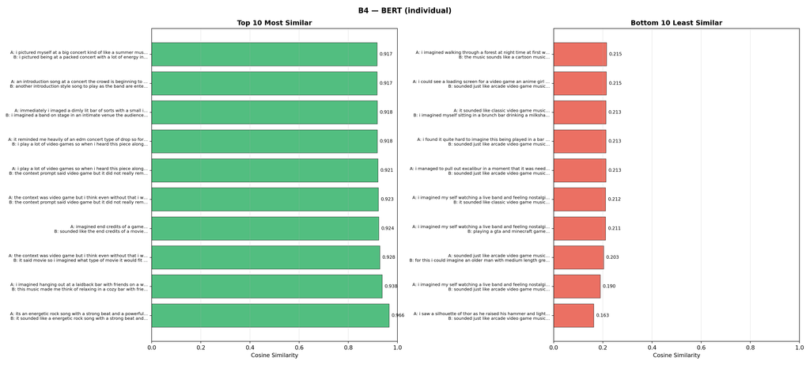

## B5 — BERTweet

**Data**: `dataMIMC_preprocessed.csv` | **Preprocessing**: `lvl1a` (light)

BERTweet pretrained on informal short text. At the individual level, where MIMC descriptions are short and conversational, the domain match is more relevant than at the combMIMC level. Comparing B4 vs B5 isolates pretraining domain while holding architecture constant at the individual scale.

```
B5 — BERTweet  (individual)
```

```
Loaded from cache: (1946, 768)
```

```
  Pairs: 1,764,380  |  skipped — identical: 11  |  short (<5 words): 128,094  |  same person/cell: 0
```

```
TOP 10:

  [1]  Sim=0.9791  |  ✗ diff clip  ✓ same context
       Met_LOW_09 / concert  vs  Jaz_LOW_19 / concert
  ── Original A: its an energetic rock song with a strong beat and a powerful electric guitar
  ── Original B: it sounded like a energetic rock song with a strong beat and a powerful electric guitar
     Model A:    its an energetic with a strong beat and a powerful electric
     Model B:    it a energetic with a strong beat and a powerful electric

  [2]  Sim=0.9675  |  ✗ diff clip  ✗ diff context
       80s_LOW_06 / concert  vs  Met_LOW_14 / movie
  ── Original A: the tune gives a driving experience
  ── Original B: the tune gives a cinematic experience

  [3]  Sim=0.9675  |  ✗ diff clip  ✓ same context
       80s_LOW_06 / concert  vs  Met_LOW_09 / concert
  ── Original A: the tune gives a driving experience
  ── Original B: the tune gives a cinematic experience

  [4]  Sim=0.9619  |  ✗ diff clip  ✗ diff context
       Met_LOW_09 / movie  vs  Met_LOW_14 / videogame
  ── Original A: sounds like a music played on background of a cinema movie
  ── Original B: sounds a music played on a background of an action movie
     Model A:    a played on background of a cinema
     Model B:    a played on a background of an action

  [5]  Sim=0.9564  |  ✗ diff clip  ✓ same context
       Jaz_LOW_19 / bar  vs  80s_MED_13 / bar
  ── Original A: at first when it was just the piano i could image it playing at an upscale and quiet bar as i could imagine a piano player performing the piece but then as the rest of the instrumental came in i could imagine it being played at a fun and lighthearted jazz bar where there is seating …
  ── Original B: i was thinking that this could play at an upscale bar initially with the delicate music that was playing initially maybe at a place with a low stage and a piano with seating around it later as the vocals came in i thought it could really set the mood for a scene in some fiction wher…
     Model A:    at first when it was just the i it at an upscale and quiet as i a player performing the but then as the rest of the came in i it being played at a fun and lighthearted where there is seating but also space for people to get up and dance to the
     Model B:    i was that this at an upscale initially with the delicate that was initially maybe at a place with a low stage and a with seating around it later as the vocals came in i it really set the mood for a in some fiction where two characters meet for the first time

  [6]  Sim=0.9564  |  ✗ diff clip  ✓ same context
       Ele_MED_20 / bar  vs  80s_LOW_06 / bar
  ── Original A: i imagined hanging out at a laidback bar with friends on a weekend the music is smooth and relaxed setting a chill mood where everyones just talking laughing and unwinding people were sitting at the bar sipping drinks and just enjoying the easygoing vibe
  ── Original B: i imagined sitting in a cozy bar with dim lights and a relaxed crowd the music has a smooth jazz feel like something youd hear late at night when everyones just unwinding people were chatting quietly sipping cocktails and just enjoying the atmosphere
     Model A:    i hanging out at a laidback with friends on a weekend the is smooth and relaxed setting a chill mood where everyones just talking laughing and unwinding people were sitting at the sipping drinks and just enjoying the easygoing vibe
     Model B:    i sitting in a cozy with dim lights and a relaxed crowd the has a smooth feel something youd hear late at night when everyones just unwinding people were chatting quietly sipping cocktails and just enjoying the atmosphere

```

[output cut: 12 more lines]

```
     Model B:    it said so i what type of it fit as a soundtrack and figured probably action or science fiction but then it also gave me strong vibes so i started that a bit too i have been very interested in terminator lately so i parts of that and the based on it especially the retro ones althoug…

  [9]  Sim=0.9548  |  ✗ diff clip  ✓ same context
       Jaz_LOW_19 / bar  vs  Ele_MED_19 / bar
  ── Original A: at first when it was just the piano i could image it playing at an upscale and quiet bar as i could imagine a piano player performing the piece but then as the rest of the instrumental came in i could imagine it being played at a fun and lighthearted jazz bar where there is seating …
  ── Original B: i was thinking that initially i could see this being played a piano at a small and intimate venue but when the beat and other elements of the instrumental kicked in i was visualising this playing over a set of speakers in a midsized bar full of younger patrons
     Model A:    at first when it was just the i it at an upscale and quiet as i a player performing the but then as the rest of the came in i it being played at a fun and lighthearted where there is seating but also space for people to get up and dance to the
     Model B:    i was that initially i see this being played a at a small and intimate venue but when the beat and other elements of the kicked in i was this over a set of speakers in a midsized full of younger patrons

  [10]  Sim=0.9546  |  ✗ diff clip  ✓ same context
       Ele_MED_20 / bar  vs  Jaz_LOW_21 / bar
  ── Original A: i imagined hanging out at a laidback bar with friends on a weekend the music is smooth and relaxed setting a chill mood where everyones just talking laughing and unwinding people were sitting at the bar sipping drinks and just enjoying the easygoing vibe
  ── Original B: this music made me think of relaxing in a cozy bar with friends the jazz vibe is smooth and mellow making the whole place feel warm and welcoming people are chatting laughing and enjoying their drinks while the music plays softly in the background
     Model A:    i hanging out at a laidback with friends on a weekend the is smooth and relaxed setting a chill mood where everyones just talking laughing and unwinding people were sitting at the sipping drinks and just enjoying the easygoing vibe
     Model B:    this me of relaxing in a cozy with friends the vibe is smooth and mellow the whole place feel warm and welcoming people are chatting laughing and enjoying their drinks while the softly in the background
```

```
BOTTOM 10:

  [1]  Sim=0.1750  |  ✗ diff clip  ✗ diff context
       Jaz_MED_02 / bar  vs  80s_LOW_02 / videogame
  ── Original A: black ops 3 zombie music
  ── Original B: i can sort of imagine a romantic scene in a movie or some kind of slow paced scene in a bar i know the actual context was a video game but it did not actually make me think of a video game necessarily it made me think of a cutscene within a video game which is kind of like a movie b…
     Model A:    black ops 3 zombie
     Model B:    i can sort of a romantic in a or some kind of slow paced in a i know the actual context was a but it did not actually me of a necessarily it me of a cutscene within a which is kind of a based cinematic in a sense it did not me feel too much i was on the fence whether to select yes o…

  [2]  Sim=0.1806  |  ✗ diff clip  ✗ diff context
       Jaz_MED_02 / bar  vs  Ele_LOW_09 / concert
  ── Original A: black ops 3 zombie music
  ── Original B: i felt like i was at a drum and bass concert i do not like that music or similar like in the clip and have never had enough energy to enjoy such a concert so it felt more annoying than emotionally good
     Model A:    black ops 3 zombie
     Model B:    i felt i was at a and bass i do not that or similar in the and have never had enough energy to enjoy such a so it felt more annoying than emotionally good

  [3]  Sim=0.1831  |  ✗ diff clip  ✓ same context
       Jaz_MED_02 / bar  vs  80s_MED_13 / bar
  ── Original A: black ops 3 zombie music
  ── Original B: i was thinking that this could play at an upscale bar initially with the delicate music that was playing initially maybe at a place with a low stage and a piano with seating around it later as the vocals came in i thought it could really set the mood for a scene in some fiction wher…
     Model A:    black ops 3 zombie
     Model B:    i was that this at an upscale initially with the delicate that was initially maybe at a place with a low stage and a with seating around it later as the vocals came in i it really set the mood for a in some fiction where two characters meet for the first time

  [4]  Sim=0.2009  |  ✗ diff clip  ✗ diff context
       Jaz_MED_02 / bar  vs  Jaz_MED_07 / concert
  ── Original A: black ops 3 zombie music
  ── Original B: i was thinking that i could easily see the scene where a female singer is on stage and the instrumental to the song she is about to perform is playing behind her are her live band who are playing the instrumental she herself is standing at her microphone stand nodding to the music a…
     Model A:    black ops 3 zombie
     Model B:    i was that i easily see the where a female is on stage and the to the she is about to perform is behind her are her live who are the she herself is standing at her microphone stand nodding to the and ready to come in when it is her cue

  [5]  Sim=0.2039  |  ✗ diff clip  ✗ diff context
       Jaz_MED_02 / bar  vs  Met_MED_19 / videogame
  ── Original A: black ops 3 zombie music
  ── Original B: the context was video game but i think even without that i would have pictured games because it sounded very typical of an older action fighting type game or maybe a science fiction racing game or something i really liked the music and imagined what kind of game it would suit as a s…
     Model A:    black ops 3 zombie
     Model B:    the context was but i even without that i have because it very typical of an older action fighting type or maybe a science fiction racing or something i really liked the and what kind of it suit as a soundtrack based on i have played in the past and my modest experience as a hobby d…

  [6]  Sim=0.2043  |  ✗ diff clip  ✗ diff context
       Jaz_MED_02 / bar  vs  80s_LOW_02 / concert
  ── Original A: black ops 3 zombie music
```

[output cut: 16 more lines]

```
     Model B:    i really see this being the extended remix of a really hype that at a kpop or jpop i was really clearly this as the opening for a designed for the idols to show off a complicated dance routine with many backup dancers to create a visual spectacle

  [9]  Sim=0.2092  |  ✗ diff clip  ✗ diff context
       Jaz_MED_02 / bar  vs  Met_MED_19 / concert
  ── Original A: black ops 3 zombie music
  ── Original B: i could easily imagine this being a punk band maybe like fall out boy during an instrumental section of their song the band i was imagining are somewhat close to the edge of the stage with fans equally pressed up against the edge of the stage i was imagining the band really into wha…
     Model A:    black ops 3 zombie
     Model B:    i easily this being a punk maybe fall out boy during an section of their the i was are somewhat close to the edge of the stage with fans equally pressed up against the edge of the stage i was the really into what they were completely lost in the

  [10]  Sim=0.2102  |  ✗ diff clip  ✓ same context
       Jaz_MED_02 / bar  vs  Jaz_LOW_19 / bar
  ── Original A: black ops 3 zombie music
  ── Original B: at first when it was just the piano i could image it playing at an upscale and quiet bar as i could imagine a piano player performing the piece but then as the rest of the instrumental came in i could imagine it being played at a fun and lighthearted jazz bar where there is seating …
     Model A:    black ops 3 zombie
     Model B:    at first when it was just the i it at an upscale and quiet as i a player performing the but then as the rest of the came in i it being played at a fun and lighthearted where there is seating but also space for people to get up and dance to the
```

```
Saved: /Users/hazelaileenvanderwalle/Library/CloudStorage/OneDrive-Personal/work/study/PhD/_PROJECT/_framedListening_NLP/context-framed-listening/NLP_outputs/model_comparison/pairs_B5_bertweet.png
```

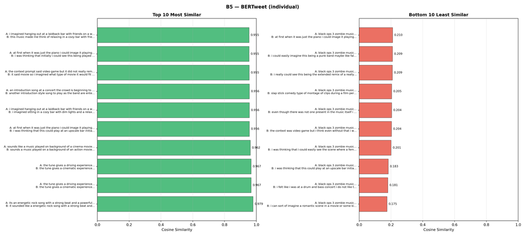

## B6 — paraphrase-MiniLM-L6-v2

**Data**: `dataMIMC_preprocessed.csv` | **Preprocessing**: `lvl1a` (light)

Paraphrase-tuned variant of MiniLM. At the individual level, different participants describing the same mental experience in different words is precisely a paraphrase task. Comparing B6 vs B7 (all-MiniLM) isolates fine-tuning objective within the same architecture on identical individual-level inputs.

```
B6 — paraphrase-MiniLM-L6-v2  (individual)
```

```
Loaded from cache: (1946, 384)
```

```
  Pairs: 1,764,380  |  skipped — identical: 11  |  short (<5 words): 128,094  |  same person/cell: 0
```

```
TOP 10:

  [1]  Sim=0.9833  |  ✗ diff clip  ✓ same context
       Met_LOW_09 / concert  vs  Jaz_LOW_19 / concert
  ── Original A: its an energetic rock song with a strong beat and a powerful electric guitar
  ── Original B: it sounded like a energetic rock song with a strong beat and a powerful electric guitar
     Model A:    its an energetic with a strong beat and a powerful electric
     Model B:    it a energetic with a strong beat and a powerful electric

  [2]  Sim=0.9808  |  ✗ diff clip  ✗ diff context
       80s_LOW_02 / videogame  vs  80s_MED_08 / concert
  ── Original A: imagined end credits of a game
  ── Original B: sounded like the end credits of a movie
     Model A:    end credits of a
     Model B:    the end credits of a

  [3]  Sim=0.9498  |  ✗ diff clip  ✗ diff context
       Met_LOW_09 / videogame  vs  Met_MED_20 / concert
  ── Original A: a band playing on a stage more of a rock heavy metal band
  ── Original B: a band on stage playing the song with big guitars like a heavy rock band
     Model A:    a on a stage more of a heavy
     Model B:    a on stage the with big a heavy

  [4]  Sim=0.9158  |  ✗ diff clip  ✗ diff context
       Jaz_LOW_19 / concert  vs  Met_LOW_14 / movie
  ── Original A: it sounded like a energetic rock song with a strong beat and a powerful electric guitar
  ── Original B: it sounded like a energetic rock song with a powerful electric guitar
     Model A:    it a energetic with a strong beat and a powerful electric
     Model B:    it a energetic with a powerful electric

  [5]  Sim=0.8969  |  ✗ diff clip  ✗ diff context
       Jaz_LOW_19 / concert  vs  Jaz_MED_02 / bar
  ── Original A: jazz music played in classy restaurants and events
  ── Original B: sounds more like cool and classy jazz music played in classy events and restaurants
     Model A:    played in classy restaurants and events
     Model B:    more cool and classy played in classy events and restaurants

  [6]  Sim=0.8942  |  ✗ diff clip  ✗ diff context
       Met_LOW_09 / concert  vs  Met_LOW_14 / movie
  ── Original A: its an energetic rock song with a strong beat and a powerful electric guitar
```

[output cut: 16 more lines]

```
     Model B:    a romantic people dancing in each others arms

  [9]  Sim=0.8744  |  ✓ same clip  ✗ diff context
       Ele_LOW_14 / bar  vs  Ele_LOW_14 / videogame
  ── Original A: sounds from a pac man arcade machine
  ── Original B: playing a video game such as pac man in an arcade
     Model A:    from a pac man arcade machine
     Model B:    a such as pac man in an arcade

  [10]  Sim=0.8676  |  ✗ diff clip  ✓ same context
       Met_MED_19 / concert  vs  Met_MED_20 / concert
  ── Original A: this also sounded like the opening scene of an anime
  ── Original B: sounds like the opening for a shonen anime
     Model A:    this also the opening of an anime
     Model B:    the opening for a shonen anime
```

```
BOTTOM 10:

  [1]  Sim=-0.2935  |  ✗ diff clip  ✓ same context
       Ele_MED_20 / concert  vs  Ele_MED_19 / concert
  ── Original A: this is the kind of background music you hear when some big tech company makes some major innovation in the sphere and decides to make a five minute long info dump explaining why this 1000 dollars smartphone is different from the one you just bought
  ── Original B: the scene i imaged would be at a chilled music festival in the countryside or woodlands and calmly dancing
     Model A:    this is the kind of background you hear when some big tech company some major innovation in the sphere and decides to a five minute long info dump explaining why this 1000 dollars smartphone is different from the one you just bought
     Model B:    the i be at a chilled festival in the countryside or woodlands and calmly dancing

  [2]  Sim=-0.2572  |  ✗ diff clip  ✗ diff context
       80s_LOW_02 / concert  vs  Jaz_LOW_19 / movie
  ── Original A: the sound was really soothing and made me imagined playing it for my pet to sleep
  ── Original B: a woman in a movie scene moving across the street in a round skirt seeing a handsome man on the other end
     Model A:    the was really soothing and me it for my pet to sleep
     Model B:    a woman in a moving across the street in a round skirt seeing a handsome man on the other end

  [3]  Sim=-0.2537  |  ✗ diff clip  ✗ diff context
       Met_LOW_09 / concert  vs  Ele_MED_20 / bar
  ── Original A: very heavy rock not for me somewhere that i do not belong did not enjoy
  ── Original B: the scene was a new computer operating system start up sound with that song being the start up sound
     Model A:    very heavy not for me somewhere that i do not belong did not enjoy
     Model B:    the was a new computer operating system start up with that being the start up

  [4]  Sim=-0.2479  |  ✗ diff clip  ✗ diff context
       Met_LOW_09 / concert  vs  Ele_LOW_09 / bar
  ── Original A: very heavy rock not for me somewhere that i do not belong did not enjoy
  ── Original B: sounds like the kind of music tech companies play when announcing a new phone
     Model A:    very heavy not for me somewhere that i do not belong did not enjoy
     Model B:    the kind of tech companies when announcing a new phone

  [5]  Sim=-0.2462  |  ✗ diff clip  ✗ diff context
       Met_LOW_09 / movie  vs  80s_MED_08 / bar
  ── Original A: i imagined the main character of a dark action movie getting their weapons and tools ready so they can plot out how to take down their enemy
  ── Original B: the music is a county music it is very enjoyable
     Model A:    i the main character of a dark action getting their weapons and tools ready so they can plot out how to take down their enemy
     Model B:    the is a county it is very enjoyable

  [6]  Sim=-0.2435  |  ✗ diff clip  ✗ diff context
       80s_LOW_02 / videogame  vs  80s_MED_13 / bar
  ── Original A: breaking up with someone who i have been dating for a long time and then they start crying
```

[output cut: 14 more lines]

```
     Model B:    i driving home after a stressful day at work and with the thoughts of how life has been unfair with me in areas where i gave in my all and did not get to achieve my goals

  [9]  Sim=-0.2375  |  ✗ diff clip  ✓ same context
       Ele_LOW_14 / bar  vs  Met_MED_19 / bar
  ── Original A: a bunch of little aliens performing a tech concert
  ── Original B: it felt like my blood was rising a bit overwhelming but also like i needed to just let lose crash out and enjoy myself
     Model A:    a bunch of little aliens performing a tech
     Model B:    it felt my blood was rising a bit overwhelming but also i needed to just let lose crash out and enjoy myself

  [10]  Sim=-0.2373  |  ✗ diff clip  ✗ diff context
       Ele_LOW_09 / videogame  vs  Met_MED_20 / movie
  ── Original A: i imagined a hacker trying his hardest to hack into a company to find out something about one of his friends it gets more and more intense as his screen shows a lot of windows and numbers with him trying his best to figure this code out he finally achieves this
  ── Original B: i enjoyed this instrumental sound it is suitable for rock and band musicals
     Model A:    i a hacker trying his hardest to hack into a company to find out something about one of his friends it gets more and more intense as his screen shows a lot of windows and numbers with him trying his best to figure this code out he finally achieves this
     Model B:    i enjoyed this it is suitable for and musicals
```

```
Saved: /Users/hazelaileenvanderwalle/Library/CloudStorage/OneDrive-Personal/work/study/PhD/_PROJECT/_framedListening_NLP/context-framed-listening/NLP_outputs/model_comparison/pairs_B6_para_minilm.png
```

[figure not shown]

## B7 — all-MiniLM-L6-v2

**Data**: `dataMIMC_preprocessed.csv` | **Preprocessing**: `lvl1a` (light)

Fine-tuned for semantic similarity. Comparing B4 vs B7 on identical inputs isolates the effect of similarity fine-tuning at the individual level.

```
B7 — all-MiniLM-L6-v2  (individual)
```

```
Loaded from cache: (1946, 384)
```

```
  Pairs: 1,764,380  |  skipped — identical: 11  |  short (<5 words): 128,094  |  same person/cell: 0
```

```
TOP 10:

  [1]  Sim=0.9901  |  ✗ diff clip  ✓ same context
       Met_LOW_09 / concert  vs  Jaz_LOW_19 / concert
  ── Original A: its an energetic rock song with a strong beat and a powerful electric guitar
  ── Original B: it sounded like a energetic rock song with a strong beat and a powerful electric guitar
     Model A:    its an energetic with a strong beat and a powerful electric
     Model B:    it a energetic with a strong beat and a powerful electric

  [2]  Sim=0.9556  |  ✗ diff clip  ✗ diff context
       80s_LOW_02 / videogame  vs  80s_MED_08 / concert
  ── Original A: imagined end credits of a game
  ── Original B: sounded like the end credits of a movie
     Model A:    end credits of a
     Model B:    the end credits of a

  [3]  Sim=0.9199  |  ✗ diff clip  ✗ diff context
       Met_LOW_09 / videogame  vs  Met_MED_20 / concert
  ── Original A: a band playing on a stage more of a rock heavy metal band
  ── Original B: a band on stage playing the song with big guitars like a heavy rock band
     Model A:    a on a stage more of a heavy
     Model B:    a on stage the with big a heavy

  [4]  Sim=0.9052  |  ✗ diff clip  ✗ diff context
       Jaz_LOW_19 / concert  vs  Met_LOW_14 / movie
  ── Original A: it sounded like a energetic rock song with a strong beat and a powerful electric guitar
  ── Original B: it sounded like a energetic rock song with a powerful electric guitar
     Model A:    it a energetic with a strong beat and a powerful electric
     Model B:    it a energetic with a powerful electric

  [5]  Sim=0.8981  |  ✗ diff clip  ✗ diff context
       Met_LOW_09 / concert  vs  Met_LOW_14 / movie
  ── Original A: its an energetic rock song with a strong beat and a powerful electric guitar
  ── Original B: it sounded like a energetic rock song with a powerful electric guitar
     Model A:    its an energetic with a strong beat and a powerful electric
     Model B:    it a energetic with a powerful electric

  [6]  Sim=0.8740  |  ✗ diff clip  ✗ diff context
       Ele_MED_20 / bar  vs  80s_LOW_02 / concert
  ── Original A: people dancing romantically in a bar
```

[output cut: 16 more lines]

```
     Model B:    more cool and classy played in classy events and restaurants

  [9]  Sim=0.8408  |  ✓ same clip  ✗ diff context
       Ele_LOW_14 / bar  vs  Ele_LOW_14 / videogame
  ── Original A: sounds from a pac man arcade machine
  ── Original B: playing a video game such as pac man in an arcade
     Model A:    from a pac man arcade machine
     Model B:    a such as pac man in an arcade

  [10]  Sim=0.8314  |  ✗ diff clip  ✗ diff context
       Ele_MED_20 / movie  vs  80s_MED_08 / bar
  ── Original A: i remembered my girlfriend love this beat so much
  ── Original B: my sister who loves songs with this beat
     Model A:    i my girlfriend love this beat so much
     Model B:    my sister who loves with this beat
```

```
BOTTOM 10:

  [1]  Sim=-0.2099  |  ✗ diff clip  ✗ diff context
       80s_MED_08 / videogame  vs  Jaz_MED_07 / concert
  ── Original A: a giant man plodding along the street with a cheery grin on his face greeting everyone as he walks past
  ── Original B: i thought of film noir crime and mystery films as well as two television series that used similar music matlock the series that aired in the 1980s and 90s and in the heat of the night this sounds like the soundtrack for a mystery or crime drama

  [2]  Sim=-0.1988  |  ✗ diff clip  ✗ diff context
       80s_LOW_06 / videogame  vs  Jaz_MED_07 / bar
  ── Original A: its the ending title sequence of a movie its playing character bloopers in between the credits
  ── Original B: made me think of jazz clubs where you can play poker and have food as well as smoke cigarettes in an underground poker club very cosy and relaxing atmosphere cigars smoke in the air
     Model A:    its the ending title sequence of a its character bloopers in between the credits
     Model B:    me of clubs where you can poker and have food as well as smoke cigarettes in an underground poker club very cosy and relaxing atmosphere cigars smoke in the air

  [3]  Sim=-0.1882  |  ✗ diff clip  ✗ diff context
       Ele_MED_19 / movie  vs  80s_LOW_06 / concert
  ── Original A: rainy stormy windows in a city apartment a girl feel reenergised and at peace by it
  ── Original B: people are dancing at the disco people perform the soul train on the stage

  [4]  Sim=-0.1876  |  ✗ diff clip  ✗ diff context
       Jaz_MED_07 / videogame  vs  Met_LOW_14 / movie
  ── Original A: people are relaxing at the jazz club people are watching the band perform
  ── Original B: an evil character making plans to kill someone in a cartoon
     Model A:    people are relaxing at the club people are watching the perform
     Model B:    an evil character plans to kill someone in a cartoon

  [5]  Sim=-0.1864  |  ✓ same clip  ✗ diff context
       80s_MED_08 / videogame  vs  80s_MED_08 / concert
  ── Original A: the character arrives at the beach section
  ── Original B: i thought about my mum she had tons of records that sounded exactly like this we would listen to these nonstop back then

  [6]  Sim=-0.1813  |  ✗ diff clip  ✗ diff context
       Met_LOW_14 / movie  vs  Ele_MED_20 / bar
  ── Original A: someone playing the guitar someone that looks like jason momoa probably because i have watched game of thrones recently then also occasionally some anime scenes
  ── Original B: feel like i am at a work conference where a company is launching a new product not bar like at all
     Model A:    someone the someone that looks jason momoa probably because i have watched of thrones recently then also occasionally some anime
     Model B:    feel i am at a work conference where a company is launching a new product not at all

  [7]  Sim=-0.1797  |  ✗ diff clip  ✗ diff context
       Ele_MED_19 / videogame  vs  Met_MED_20 / concert
```

[output cut: 8 more lines]

```
  ── Original B: the pianist is on stage playing his keys while the singer and dancers are waiting for their cue to begin performing
     Model A:    it brought a where things were in a chaotic mess for me i had just lost my job and i not straight back then so i usually hard i that my worry less
     Model B:    the is on stage his keys while the and dancers are waiting for their cue to begin performing

  [9]  Sim=-0.1769  |  ✗ diff clip  ✗ diff context
       Met_LOW_09 / bar  vs  80s_LOW_06 / movie
  ── Original A: i saw a silhouette of thor as he raised his hammer and lightning struck revealing his visage a warrior wearing an elk skull rose from the ground with his mighty axe in hand and he began charging
  ── Original B: scenes of the city a tropical city like miami and or los angeles

  [10]  Sim=-0.1750  |  ✓ same clip  ✗ diff context
       Met_LOW_09 / concert  vs  Met_LOW_09 / movie
  ── Original A: i once attended a concert and have definitely heard similar sounds i was trying to remember when it was but i could not
  ── Original B: i imagined the main character of a dark action movie getting their weapons and tools ready so they can plot out how to take down their enemy
     Model A:    i once attended a and have definitely heard similar i was trying to when it was but i not
     Model B:    i the main character of a dark action getting their weapons and tools ready so they can plot out how to take down their enemy
```

```
Saved: /Users/hazelaileenvanderwalle/Library/CloudStorage/OneDrive-Personal/work/study/PhD/_PROJECT/_framedListening_NLP/context-framed-listening/NLP_outputs/model_comparison/pairs_B7_minilm.png
```

[figure not shown]

## B8 — all-mpnet-base-v2

**Data**: `dataMIMC_preprocessed.csv` | **Preprocessing**: `lvl1a` (light)

Quality ceiling for the individual-level sentence-embedding models.

```
B8 — all-mpnet-base-v2  (individual)
```

```
Loaded from cache: (1946, 768)
```

```
  Pairs: 1,764,380  |  skipped — identical: 11  |  short (<5 words): 128,094  |  same person/cell: 0
```

```
TOP 10:

  [1]  Sim=0.9837  |  ✗ diff clip  ✓ same context
       Met_LOW_09 / concert  vs  Jaz_LOW_19 / concert
  ── Original A: its an energetic rock song with a strong beat and a powerful electric guitar
  ── Original B: it sounded like a energetic rock song with a strong beat and a powerful electric guitar
     Model A:    its an energetic with a strong beat and a powerful electric
     Model B:    it a energetic with a strong beat and a powerful electric

  [2]  Sim=0.8766  |  ✗ diff clip  ✗ diff context
       80s_LOW_02 / videogame  vs  80s_MED_08 / concert
  ── Original A: imagined end credits of a game
  ── Original B: sounded like the end credits of a movie
     Model A:    end credits of a
     Model B:    the end credits of a

  [3]  Sim=0.8760  |  ✗ diff clip  ✗ diff context
       Met_LOW_09 / videogame  vs  Met_MED_20 / concert
  ── Original A: a band playing on a stage more of a rock heavy metal band
  ── Original B: a band on stage playing the song with big guitars like a heavy rock band
     Model A:    a on a stage more of a heavy
     Model B:    a on stage the with big a heavy

  [4]  Sim=0.8387  |  ✗ diff clip  ✗ diff context
       Jaz_MED_07 / movie  vs  80s_LOW_02 / videogame
  ── Original A: i imagined myself seated in my house balcony while my mind is being overcame by thoughts
  ── Original B: i imagined myself seated in my house just meditating about my life
     Model A:    i myself seated in my house balcony while my mind is being overcame by thoughts
     Model B:    i myself seated in my house just meditating about my life

  [5]  Sim=0.8298  |  ✗ diff clip  ✓ same context
       Met_LOW_14 / movie  vs  Ele_LOW_09 / movie
  ── Original A: i imagined a movie scene where the protagonist is chasing after the villain
  ── Original B: i imagined an action movie where someone is being pursued by villains
     Model A:    i a where the protagonist is chasing after the villain
     Model B:    i an action where someone is being pursued by villains

  [6]  Sim=0.8247  |  ✗ diff clip  ✓ same context
       80s_LOW_02 / videogame  vs  80s_LOW_06 / videogame
  ── Original A: it reminded me of 80s music videos for some reason
```

[output cut: 14 more lines]

```
  ── Original B: dark room with some strobe lighting and a dance floor with a dj sitting behind it theres a lot of people and its really crowded everyone is drinking or sitting next to the bar

  [9]  Sim=0.8191  |  ✗ diff clip  ✗ diff context
       Jaz_MED_02 / movie  vs  80s_LOW_02 / concert
  ── Original A: sounds like music played at a bar or fancy restaurant
  ── Original B: played at a jazz club or a bistro
     Model A:    played at a or fancy restaurant
     Model B:    played at a club or a bistro

  [10]  Sim=0.8169  |  ✗ diff clip  ✓ same context
       Met_LOW_14 / concert  vs  Met_MED_20 / concert
  ── Original A: stage lights are flashing and strobing the crowd are getting really into the music a small part of the crowd near the front are moshing whilst other dotted throughout the crowd are headbanging
  ── Original B: its a rock concert the crowd is one big mass and everyone is surging forward lots of lights and some fire around the stage while the band is dancing and playing
     Model A:    stage lights are flashing and strobing the crowd are getting really into the a small part of the crowd near the front are moshing whilst other dotted throughout the crowd are headbanging
     Model B:    its a the crowd is one big mass and everyone is surging forward lots of lights and some fire around the stage while the is dancing and
```

```
BOTTOM 10:

  [1]  Sim=-0.2387  |  ✗ diff clip  ✗ diff context
       Met_LOW_14 / movie  vs  Ele_MED_19 / bar
  ── Original A: an evil character making plans to kill someone in a cartoon
  ── Original B: it felt really good to listen i imagined a scene where i was on vacation with my partner in a cozy setting fireplace and good music vibes
     Model A:    an evil character plans to kill someone in a cartoon
     Model B:    it felt really good to listen i a where i was on vacation with my partner in a cozy setting fireplace and good vibes

  [2]  Sim=-0.2005  |  ✗ diff clip  ✗ diff context
       Met_LOW_14 / movie  vs  80s_MED_08 / bar
  ── Original A: an evil character making plans to kill someone in a cartoon
  ── Original B: this was interesting imagined myself dancing in a bar with a beautiful lady holding each other closely
     Model A:    an evil character plans to kill someone in a cartoon
     Model B:    this was interesting myself dancing in a with a beautiful lady holding each other closely

  [3]  Sim=-0.1957  |  ✗ diff clip  ✓ same context
       Met_LOW_14 / movie  vs  Ele_MED_20 / movie
  ── Original A: an evil character making plans to kill someone in a cartoon
  ── Original B: getting a massage from a masseuse it felt very much like the music they play rhythmic but calming
     Model A:    an evil character plans to kill someone in a cartoon
     Model B:    getting a massage from a masseuse it felt very much the they rhythmic but calming

  [4]  Sim=-0.1918  |  ✗ diff clip  ✗ diff context
       80s_LOW_02 / videogame  vs  Met_MED_19 / movie
  ── Original A: a man walking down a dark street in heavy rain looking upset the only light is the street lighting
  ── Original B: i think it would be cool to learn how to play the guitar as well but i do not know if its too late to learn now being in a band sounds very cool

  [5]  Sim=-0.1856  |  ✗ diff clip  ✗ diff context
       Met_LOW_14 / movie  vs  80s_LOW_02 / concert
  ── Original A: an evil character making plans to kill someone in a cartoon
  ── Original B: it made me feel like i was walking through a forest as it was so calming and surreal sounding i could imagine the sun on my face
     Model A:    an evil character plans to kill someone in a cartoon
     Model B:    it me feel i was walking through a forest as it was so calming and surreal i the sun on my face

  [6]  Sim=-0.1809  |  ✗ diff clip  ✓ same context
       Jaz_MED_07 / movie  vs  Ele_LOW_09 / movie
  ── Original A: it sounds like a lonely man is in a bar reflecting on his life
  ── Original B: an action movie with neon lighting people are racing cars down the street
     Model A:    it a lonely man is in a reflecting on his life
```

[output cut: 14 more lines]

```
     Model B:    yes i walking into a posh drinking with this type of its relaxing

  [9]  Sim=-0.1732  |  ✗ diff clip  ✗ diff context
       80s_LOW_02 / movie  vs  Jaz_LOW_21 / concert
  ── Original A: a black and white mafia film where the protagonist gets told by the woman hes been slowly falling in love with that shes happily married he watches her walk away its bittersweet
  ── Original B: i wanted a xylophone as a child i think it would still be cool to have one or to be able to play an instrument in general
     Model A:    a black and white mafia where the protagonist gets told by the woman hes been slowly falling in love with that shes happily married he watches her walk away its bittersweet
     Model B:    i wanted a as a child i it still be cool to have one or to be able to an in general

  [10]  Sim=-0.1715  |  ✗ diff clip  ✓ same context
       Met_LOW_14 / movie  vs  Jaz_MED_07 / movie
  ── Original A: an evil character making plans to kill someone in a cartoon
  ── Original B: i felt like i was in a calm high end bar after a stressful day drinking a luxury drink while enjoying my evening listening to soothing music
     Model A:    an evil character plans to kill someone in a cartoon
     Model B:    i felt i was in a calm high end after a stressful day drinking a luxury drink while enjoying my evening listening to soothing
```

```
Saved: /Users/hazelaileenvanderwalle/Library/CloudStorage/OneDrive-Personal/work/study/PhD/_PROJECT/_framedListening_NLP/context-framed-listening/NLP_outputs/model_comparison/pairs_B8_mpnet.png
```

[figure not shown]

## B9 — paraphrase-mpnet-base-v2

**Data**: `dataMIMC_preprocessed.csv` | **Preprocessing**: `lvl1a` (light)

Fine-tuned for paraphrase detection. At the individual level, the paraphrase objective is especially relevant — different participants describing the same experience in their own words is structurally a paraphrase task.

```
B9 — paraphrase-mpnet-base-v2  (individual)
```

```
Loaded from cache: (1946, 768)
```

```
  Pairs: 1,764,380  |  skipped — identical: 11  |  short (<5 words): 128,094  |  same person/cell: 0
```

```
TOP 10:

  [1]  Sim=0.9891  |  ✗ diff clip  ✓ same context
       Met_LOW_09 / concert  vs  Jaz_LOW_19 / concert
  ── Original A: its an energetic rock song with a strong beat and a powerful electric guitar
  ── Original B: it sounded like a energetic rock song with a strong beat and a powerful electric guitar
     Model A:    its an energetic with a strong beat and a powerful electric
     Model B:    it a energetic with a strong beat and a powerful electric

  [2]  Sim=0.9415  |  ✗ diff clip  ✗ diff context
       80s_LOW_02 / videogame  vs  80s_MED_08 / concert
  ── Original A: imagined end credits of a game
  ── Original B: sounded like the end credits of a movie
     Model A:    end credits of a
     Model B:    the end credits of a

  [3]  Sim=0.9286  |  ✗ diff clip  ✗ diff context
       Met_LOW_09 / videogame  vs  Met_MED_20 / concert
  ── Original A: a band playing on a stage more of a rock heavy metal band
  ── Original B: a band on stage playing the song with big guitars like a heavy rock band
     Model A:    a on a stage more of a heavy
     Model B:    a on stage the with big a heavy

  [4]  Sim=0.9273  |  ✗ diff clip  ✓ same context
       Jaz_LOW_21 / bar  vs  Met_LOW_09 / bar
  ── Original A: it reminds me of my early twenties when i was in college i used to party a lot and go to the bars
  ── Original B: reminds me of my college days when i used to party a lot
     Model A:    it me of my early twenties when i was in college i used to party a lot and go to the
     Model B:    me of my college days when i used to party a lot

  [5]  Sim=0.8912  |  ✗ diff clip  ✗ diff context
       Jaz_MED_02 / movie  vs  80s_LOW_02 / concert
  ── Original A: sounds like music played at a bar or fancy restaurant
  ── Original B: played at a jazz club or a bistro
     Model A:    played at a or fancy restaurant
     Model B:    played at a club or a bistro

  [6]  Sim=0.8908  |  ✗ diff clip  ✓ same context
       Met_MED_19 / concert  vs  Met_MED_20 / concert
  ── Original A: this also sounded like the opening scene of an anime
```

[output cut: 16 more lines]

```
     Model B:    it reminded me of a 70s era vibe

  [9]  Sim=0.8689  |  ✗ diff clip  ✓ same context
       Jaz_MED_02 / concert  vs  80s_MED_13 / concert
  ── Original A: an introduction song at a concert the crowd is beginning to buzz with excitement as the band are all making their way to the stage loud cheers are erupting each time one of the band members enters the feeling of tension within the crowd as they anticipate the entrance of the band is…
  ── Original B: another introduction style song to play as the band are entering the stage people are getting excited there is a bustling among the crowd as the band members are entering the stage
     Model A:    an introduction at a the crowd is beginning to buzz with excitement as the are all their way to the stage loud cheers are erupting each time one of the members enters the feeling of tension within the crowd as they anticipate the entrance of the is lifting
     Model B:    another introduction style to as the are entering the stage people are getting excited there is a bustling among the crowd as the members are entering the stage

  [10]  Sim=0.8657  |  ✓ same clip  ✗ diff context
       Ele_LOW_14 / bar  vs  Ele_LOW_14 / videogame
  ── Original A: sounds from a pac man arcade machine
  ── Original B: playing a video game such as pac man in an arcade
     Model A:    from a pac man arcade machine
     Model B:    a such as pac man in an arcade
```

```
BOTTOM 10:

  [1]  Sim=-0.2481  |  ✗ diff clip  ✗ diff context
       Ele_MED_19 / videogame  vs  Jaz_LOW_21 / concert
  ── Original A: for this i could imagine an older man with medium length grey hair and glasses pictured in a cafe diner with a hot drink with steam coming out pondering something with serious intent i could image from this the scene zooms out showing him through the window an a wider shot of the ci…
  ── Original B: a ballet class with kids dancing around in tutus
     Model A:    for this i an older man with medium length grey hair and glasses in a cafe diner with a hot drink with steam coming out pondering something with serious intent i from this the zooms out showing him through the window an a wider shot of the city which looks a gotham new york type of …
     Model B:    a ballet class with kids dancing around in tutus

  [2]  Sim=-0.1740  |  ✗ diff clip  ✗ diff context
       80s_LOW_02 / movie  vs  Jaz_LOW_21 / concert
  ── Original A: another detective story the detectives partner had just been murdered and he sits alone smoking in a bar they were friends maybe a bit more than that in another life time he knows he cannot work this case but damn it if he wont try everything he can to catch the killer
  ── Original B: a ballet class with kids dancing around in tutus
     Model A:    another detective the detectives partner had just been murdered and he sits alone smoking in a they were friends maybe a bit more than that in another life time he knows he can not work this case but damn it if he wont try everything he can to catch the killer
     Model B:    a ballet class with kids dancing around in tutus

  [3]  Sim=-0.1685  |  ✗ diff clip  ✗ diff context
       Ele_MED_19 / videogame  vs  Jaz_LOW_21 / concert
  ── Original A: for this i could imagine an older man with medium length grey hair and glasses pictured in a cafe diner with a hot drink with steam coming out pondering something with serious intent i could image from this the scene zooms out showing him through the window an a wider shot of the ci…
  ── Original B: i imagined children doing ballet dancing at school
     Model A:    for this i an older man with medium length grey hair and glasses in a cafe diner with a hot drink with steam coming out pondering something with serious intent i from this the zooms out showing him through the window an a wider shot of the city which looks a gotham new york type of …
     Model B:    i children doing ballet dancing at school

  [4]  Sim=-0.1512  |  ✗ diff clip  ✗ diff context
       Ele_MED_19 / movie  vs  Jaz_LOW_21 / videogame
  ── Original A: very confusing i immediately imagined oh they be dead and its so sad and everyone is at the funeral and mourning then there was this beat that was so entirely unexpected it became they be dead yes but they loved a kick drum
  ── Original B: a kid playing a video game on his tablet or ipad
     Model A:    very confusing i immediately oh they be dead and its so sad and everyone is at the funeral and mourning then there was this beat that was so entirely unexpected it became they be dead yes but they loved a kick
     Model B:    a kid a on his tablet or ipad

  [5]  Sim=-0.1492  |  ✗ diff clip  ✗ diff context
       Met_LOW_09 / movie  vs  Jaz_LOW_21 / concert
  ── Original A: i imagined a motorbike scene from a movie the motorbike moving fast paced through a city
  ── Original B: a ballet class with kids dancing around in tutus
     Model A:    i a motorbike from a the motorbike moving fast paced through a city
     Model B:    a ballet class with kids dancing around in tutus

  [6]  Sim=-0.1445  |  ✗ diff clip  ✓ same context
       80s_LOW_02 / videogame  vs  Jaz_LOW_21 / videogame
  ── Original A: a man walking down a dark street in heavy rain looking upset the only light is the street lighting
```

[output cut: 8 more lines]

```
       80s_LOW_02 / videogame  vs  Jaz_LOW_21 / videogame
  ── Original A: a man walking down a dark street in heavy rain looking upset the only light is the street lighting
  ── Original B: it was very joyful and reminded me of playing childhood computer games

  [9]  Sim=-0.1373  |  ✗ diff clip  ✗ diff context
       80s_LOW_06 / concert  vs  Met_LOW_14 / bar
  ── Original A: a random day in a sunny shopping district
  ── Original B: my exboyfriends step dad loved the band kiss and he would always play their music in his room and that is exactly what i thought about when i heard this song playing it brought some sad memories because our relationship did not end well

  [10]  Sim=-0.1340  |  ✓ same clip  ✗ diff context
       Met_LOW_09 / concert  vs  Met_LOW_09 / movie
  ── Original A: i once attended a concert and have definitely heard similar sounds i was trying to remember when it was but i could not
  ── Original B: our hero has reached a breaking point and plans to kick so major butt someone messed with the wrong person hes packing a bag putting clothes medical supplies weapons anything he may need to take down the big guy before leaving his industrial style apartment and getting on his big mo…
     Model A:    i once attended a and have definitely heard similar i was trying to when it was but i not
     Model B:    our hero has reached a breaking point and plans to kick so major butt someone messed with the wrong person hes packing a bag putting clothes medical supplies weapons anything he may need to take down the big guy before leaving his industrial style apartment and getting on his big mo…
```

```
Saved: /Users/hazelaileenvanderwalle/Library/CloudStorage/OneDrive-Personal/work/study/PhD/_PROJECT/_framedListening_NLP/context-framed-listening/NLP_outputs/model_comparison/pairs_B9_para.png
```

[figure not shown]

## Group B — Cross-Model Comparison

```
=================================================================
Group B — Rank Correlation of Pair Similarity Orderings
=================================================================
Saved: /Users/hazelaileenvanderwalle/Library/CloudStorage/OneDrive-Personal/work/study/PhD/_PROJECT/_framedListening_NLP/context-framed-listening/NLP_outputs/model_comparison/groupB_rank_correlation.png

RANK CORRELATION MATRIX — Group B
  (Pearson r on ranked pairwise similarity scores)
                                  TF-IDF       W2V-lvl2a       W2V-lvl1a            BERT        BERTweet     para-MiniLM          MiniLM           mpnet      para-mpnet
  ----------------------------------------------------------------------------------------------------------------------------------------------------------------------
  TF-IDF                          1.000*          0.397*          0.301*          0.283*          0.234*          0.227*          0.244*          0.227*          0.229*
  W2V-lvl2a                                       1.000*          0.743*          0.655*          0.517*          0.313*          0.355*          0.344*          0.322*
  W2V-lvl1a                                                       1.000*          0.734*          0.659*          0.279*          0.321*          0.329*          0.312*
  BERT                                                                            1.000*          0.737*          0.297*          0.351*          0.391*          0.356*
  BERTweet                                                                                        1.000*          0.275*          0.304*          0.325*          0.327*
  para-MiniLM                                                                                                     1.000*          0.707*          0.592*          0.726*
  MiniLM                                                                                                                          1.000*          0.714*          0.670*
  mpnet                                                                                                                                           1.000*          0.712*
  para-mpnet                                                                                                                                                      1.000*
  * p < .05
Saved: /Users/hazelaileenvanderwalle/Library/CloudStorage/OneDrive-Personal/work/study/PhD/_PROJECT/_framedListening_NLP/context-framed-listening/NLP_outputs/model_comparison/groupB_jaccard_top.png
Saved: /Users/hazelaileenvanderwalle/Library/CloudStorage/OneDrive-Personal/work/study/PhD/_PROJECT/_framedListening_NLP/context-framed-listening/NLP_outputs/model_comparison/groupB_jaccard_bottom.png
Saved: /Users/hazelaileenvanderwalle/Library/CloudStorage/OneDrive-Personal/work/study/PhD/_PROJECT/_framedListening_NLP/context-framed-listening/NLP_outputs/model_comparison/groupB_distributions.png

SUMMARY STATISTICS — Group B
Model                      Mean   Median       SD      Min      Max
------------------------------------------------------------------
  TF-IDF                 0.0093   0.0000   0.0337   0.0000   1.0000
  W2V-lvl2a              0.3818   0.3838   0.1365  -0.1537   1.0000
  W2V-lvl1a              0.5581   0.5784   0.1536  -0.1537   1.0000
  BERT                   0.6354   0.6470   0.1018   0.0601   1.0000
  BERTweet               0.7700   0.7883   0.0871   0.1421   1.0000
  para-MiniLM            0.1842   0.1760   0.1251  -0.2935   1.0000
  MiniLM                 0.1725   0.1629   0.1097  -0.2099   1.0000
  mpnet                  0.1874   0.1753   0.1174  -0.2387   1.0000
  para-mpnet             0.2356   0.2246   0.1171  -0.2481   1.0000
Saved: /Users/hazelaileenvanderwalle/Library/CloudStorage/OneDrive-Personal/work/study/PhD/_PROJECT/_framedListening_NLP/context-framed-listening/NLP_outputs/model_comparison/groupB_cross_model_heatmap.png

CROSS-MODEL SCORES — Group B (reference: MiniLM top/bottom 10 pairs)
================================================================================

```

[output cut: 244 more lines]

```
    mpnet                          -0.0335
    para-mpnet                     -0.0650

  [BOTTOM]
  A: i once attended a concert and have definitely heard similar sounds i was trying to remember when it was but i could not
  B: i imagined the main character of a dark action movie getting their weapons and tools ready so they can plot out how to take down their enemy
    TF-IDF                         0.0000
    W2V-lvl2a                      0.4125
    W2V-lvl1a                      0.6233
    BERT                           0.5809
    BERTweet                       0.7701
    para-MiniLM                    -0.1015
    MiniLM                         -0.1750
    mpnet                          -0.0588
    para-mpnet                     -0.0276
```

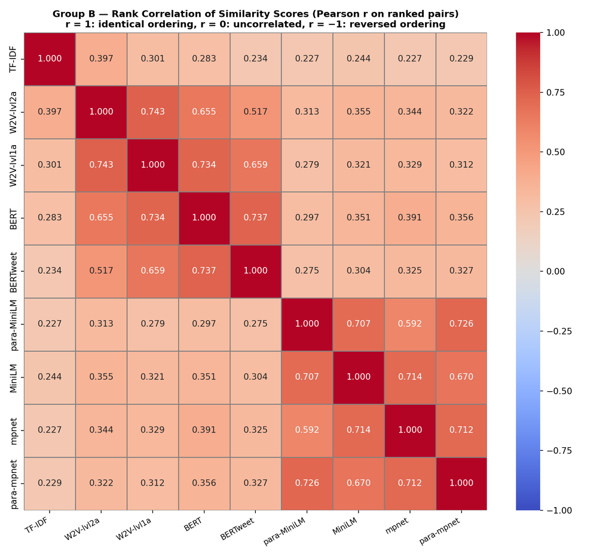

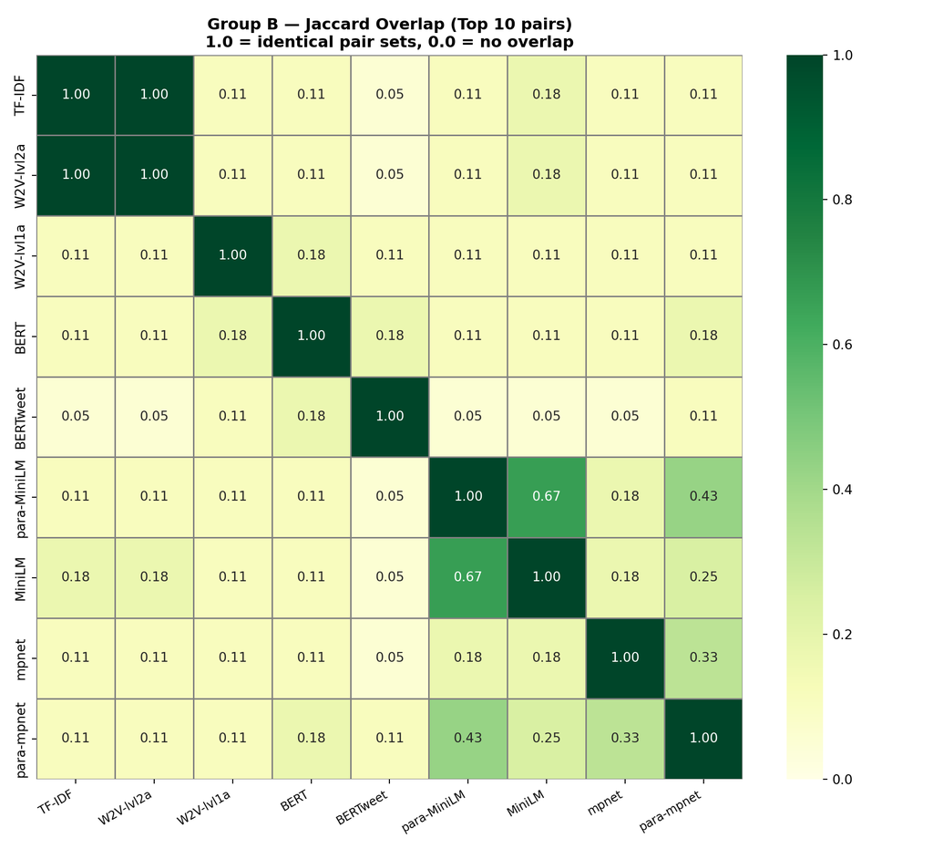

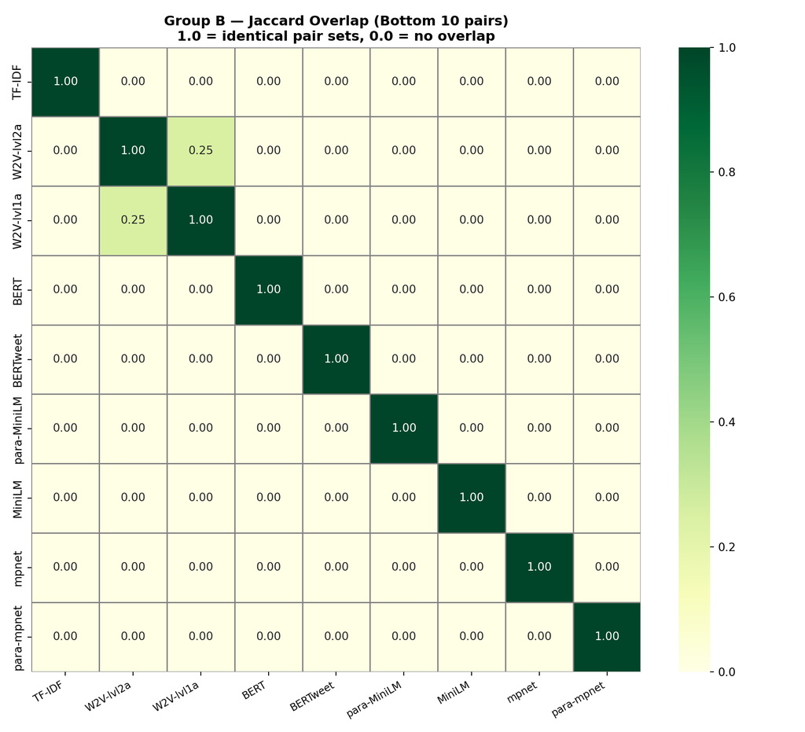

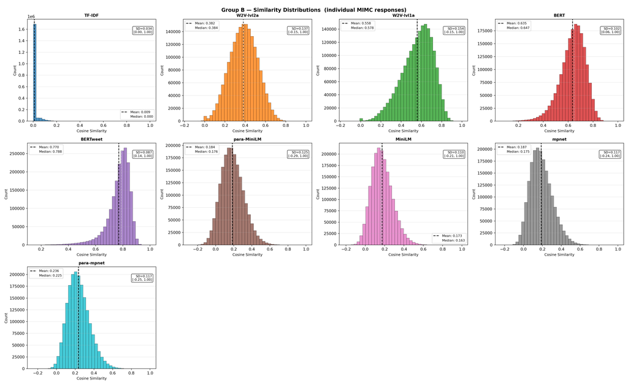

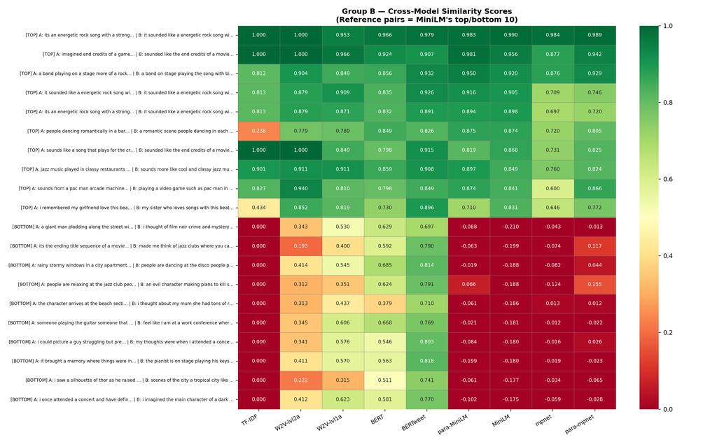

## Summary

```
FULL MODEL COMPARISON SUMMARY  (9 models × 2 data levels)
```

```
Group A: 64 combMIMC documents  |  Group B: 1946 individual responses  |  Top/bottom N: 10
```

```
  Model            Preproc    --- Group A (combMIMC) ---   --- Group B (individual) ---
```

```
                               Mean     SD    Min    Max    Mean     SD    Min    Max
```

```
  TF-IDF           lvl2a      0.126  0.036  0.050  0.321   0.009  0.034  0.000  1.000
  W2V              lvl2a      0.920  0.026  0.811  0.978   0.382  0.137 -0.154  1.000
  W2V              lvl1a      0.965  0.012  0.912  0.988   0.558  0.154 -0.154  1.000
  BERT             lvl1a      0.961  0.010  0.909  0.983   0.635  0.102  0.060  1.000
  BERTweet         lvl1a      0.943  0.013  0.865  0.973   0.770  0.087  0.142  1.000
  para-MiniLM      lvl1a      0.470  0.102  0.153  0.761   0.184  0.125 -0.293  1.000
  MiniLM           lvl1a      0.432  0.107  0.137  0.755   0.173  0.110 -0.210  1.000
  mpnet            lvl1a      0.705  0.079  0.337  0.899   0.187  0.117 -0.239  1.000
  para-mpnet       lvl1a      0.656  0.076  0.388  0.874   0.236  0.117 -0.248  1.000
```

```
Outputs saved to: /Users/hazelaileenvanderwalle/Library/CloudStorage/OneDrive-Personal/work/study/PhD/_PROJECT/_framedListening_NLP/context-framed-listening/NLP_outputs/model_comparison
```

```
  pairs_top/bottom_<ID>.csv — pair lists for each of the 18 model runs
```

```
  pairs_<ID>.png            — bar charts
```

```
  groupA/B_rank_correlation.png     — Pearson r on ranked pair orderings
```

```
  groupA/B_jaccard_top/bottom.png   — agreement heatmaps
```

```
  groupA/B_distributions.png        — score distributions
```

```
  groupA/B_cross_model_heatmap.png  — side-by-side score heatmaps
```

```
  groupA/B_cross_model_scores.csv   — full comparison tables
```